# Lab 3

## Group 4 : Kristi Herman, Rudranil Mitra, Simerpreet Reddy, Samuel VonPaays Soh

Notebook -> https://nbviewer.jupyter.org/github/RudranilMitra/DS7331_Lab1/blob/main/DS_7331_Lab3_Herman_Mitra_Reddy_VonPaaysSoh.ipynb

- Business Understanding 1
- Data Understanding 1
- Data Understanding 2
- Modeling and Evaluation 1
- Modeling and Evaluation 2
- Modeling and Evaluation 3
- Modeling and Evaluation 4
- Deployment
- Exceptional Work

## Business Understanding 1

#### *Describe the purpose of the data set you selected (i.e., why was this data collected in the first place?)*

This dataset was collected to model and predict prices for used cars and trucks listed for sale on Craigslist U.S. regional sites. For this project, classification and clustering techniques are used to predict the price range of a car. We are using 'Craigslist cars and trucks data' from Kaggle: https://www.kaggle.com/austinreese/craigslist-carstrucks-data. The author of this dataset used web scraping algorithms to gather information for used vehicles from all regional Craigslist sites in the U.S that were posted between 10/28/2020 and 12/3/2020. The original dataset contained 458,213 rows with 26 fields. After cleaning the data in Lab 1, the final dataset has 137,526 rows and 16 columns.

#### *How will you measure the effectiveness of a good algorithm?*

We will be using clustering techniques in this project with the goal of adding the cluster outputs to a Random Forest classification model to see if the clusters add any value to the selected classification model. Random Forest was chosen because it produced the best model with this dataset in Lab 2.

**Evaluating Clusters:**

- Silhouette Score: The Silhouette score will be used to assess the effectiveness of a clustering technique. The Silhouette coefficient is used to compute the density of clusters by the model when the ground truth about the dataset is unknown. The score is computed by averaging the Silhouette coefficient for each sample, computed as the difference between the average intra-cluster distance and the mean nearest-cluster distance for each sample, normalized by the maximum value. This produces a score between -1 and 1, where 1 is highly dense clusters and -1 is completely incorrect clustering.  
  Reference: https://www.scikit-yb.org/en/latest/api/cluster/silhouette.html
- Gini Index: Gini Index, also known as Gini impurity, calculates the amount of probability of a specific feature that is classified incorrectly when selected randomly. If all the elements are linked with a single class then it is considered pure. Gini index values vary between values 0 and 1, where 0 expresses the purity of classification, i.e. all the elements belong to a specified class or only one class exists there. And 1 indicates the random distribution of elements across various classes. The value of 0.5 of the Gini Index shows an equal distribution of elements over some classes.  
  Reference: https://medium.com/analytics-steps/understanding-the-gini-index-and-information-gain-in-decision-trees-ab4720518ba8

**Evaluating Classification Models:** For each clustering technique, we will add the cluster output as a feature to the dataset, we will then create classification models to evaluate if the corrsponding clusters help improve model performance. We will perform 10-fold cross validation and the following validation metrics will be used to assess the performance of the classification models:

- Accuracy: Accuracy measures the number of correct predictions by dividing the correct predictions by total predictions. The overall accuracy of each model will be measured.
- Precision: Precision is how accurate a model is when a positive prediction is made. It is a measurement of True Positive predictions divided by Total Positive predictions. Because this is a five-class problem, Precision will be evaluated for each class and averaged over all the classes to get a Precision value for each model.
- Recall: Recall is how accurate a model is at identifying True Positives. It is measured by dividing True Positive predictions by Actual Positive values. This will also be measured by class and averaged.
- F1: The F1 score attempts to balance Precision and Recall metrics. Because this analysis does not the require preference of one over the other, this score will be evaluated as well. These metrics are measured as a pecentage between 0 - 100 with higher scores indicating a better predictive model. As the response variable in this dataset is balanced, Accuracy is a good indicator of the overall model performance. In predicting the price_range of a car, we are not biased towards false positives or false negatives. Thus, we will be paying more attention to the overall F1 score of the models.

#### *Why does your chosen validation method make sense for this specific dataset and the stakeholders needs?*

The reason for the collection of this data was to predict the price/price-range of a car listed on Craigslist. We have built Classification models for this purpose and have also implemented clustering techniques. Stakeholders would be interested in how accurate the classification model is. Therefore, the above mentioned metrics of assessing classification models are appropriate. As we are adding clusters to this dataset, it is important to see how much information gain can be achieved with the clusters. Thus, the silhouette score and gini index play an important role in assessing the clusters.

## Data Understanding 1

#### *Describe the meaning and type of data (scale, values, etc.) for each attribute in the data file.*

The original dataset contained 458,213 rows with 26 fields. We cleaned the dataset as part of Lab 1 and our final dataset has 137,526 rows and 16 columns. For modeling purposes, a separate column was created for each categorical column using the get_dummies function (one hot encoding). After one hot enconding, the dataset has 137,526 rows and 121 columns.

A summary of 'Data cleanse (missing values/ duplicates/ outliers/ mistakes)' and 'New Features' is provided in the section Data Understanding 2. Additional details and the corresponding code can be found in the Lab 1 and Mini-Lab assignments: https://nbviewer.jupyter.org/github/RudranilMitra/DS7331_Lab1/blob/main/ML%20-%20Group%20Project%201.ipynb  
https://nbviewer.jupyter.org/github/RudranilMitra/DS7331_Lab1/blob/main/DS_7331_Mini_Lab_Mitra_Reddy_VonPaaysSoh_Herman.ipynb

```python
#import libraries
import pandas as pd
import numpy as np
import seaborn as sns
import matplotlib.pyplot as plt
from sklearn import metrics as mt
import warnings
warnings.simplefilter('ignore', DeprecationWarning)
from sklearn.model_selection import ShuffleSplit
from sklearn.model_selection import train_test_split
from sklearn.model_selection import StratifiedKFold, cross_val_score
from sklearn.metrics import accuracy_score, precision_score, recall_score, f1_score, make_scorer
from sklearn.model_selection import cross_validate
from sklearn.cluster import KMeans
import seaborn as sns

%matplotlib inline
```

```python
#original dataset
car_df=pd.read_csv("data/vehicles.csv")
car_df = car_df.drop(['Unnamed: 0','id','url','region','region_url','lat','long' ],axis=1)
```

```python
#Clean dataset from Lab 2
car_df1=pd.read_csv("data/out.csv")
car_df1=car_df1[['price','price_range', 'manufacturer', 'model', 'condition_new', 'cylinders', 'fuel', 'odometer',
       'title_status' , 'transmission_new', 'drive_new','type_new','paint_color_new', 'state',
       'car_Age_in_yrs']]
car_df1.info()
```

```
<class 'pandas.core.frame.DataFrame'>
RangeIndex: 137526 entries, 0 to 137525
Data columns (total 15 columns):
 #   Column            Non-Null Count   Dtype
---  ------            --------------   -----
 0   price             137526 non-null  int64
 1   price_range       137526 non-null  object
 2   manufacturer      137526 non-null  object
 3   model             137526 non-null  object
 4   condition_new     137526 non-null  object
 5   cylinders         137526 non-null  int64
 6   fuel              137526 non-null  object
 7   odometer          137526 non-null  float64
 8   title_status      137526 non-null  object
 9   transmission_new  137526 non-null  object
 10  drive_new         137526 non-null  object
 11  type_new          137526 non-null  object
 12  paint_color_new   137526 non-null  object
 13  state             137526 non-null  object
 14  car_Age_in_yrs    137526 non-null  float64
dtypes: float64(2), int64(2), object(11)
memory usage: 15.7+ MB
```

```python
%%html
<style>
table {float:left}
</style>
```

| Field Name | Description | Type | Scale |
| --- | --- | --- | --- |
| price | The price of the vehicle in US dollars. | integer | ratio |
| price_range | Price category derived from the "price" field, e.g., <1,000, 1,000 - 5,000, 5,000 - 10,000, etc. | category | ordinal |
| manufacturer | Manufacturer of the vehicle, e.g., honda, jeep, etc. There are 40 unique values. | category | nominal |
| model | Model of the vehicle, e.g., f150, malibue, etc. There are around 13,000 unique models. | category | nominal |
| condition_new | Condition of the car with 4 values (salvage, fair_good, excellent_likenew, new). This field combined some of the values in the original "condition" field. | category | ordinal |
| cylinders | Number of cylinders in the car ranging from 2 to 12. | integer | interval |
| fuel | Type of fuel with the following categories: 'gas', 'diesel', 'other', 'hybrid', 'electric'. | category | nominal |
| odometer | Mileage listed for the vehicle. | integer | ratio |
| title_status | The title status is of the vehicle: 'clean', 'lien', 'missing', 'salvage', 'rebuilt', 'parts only'. | category | nominal |
| transmission_new | Type of transmission: 'other', 'automatic', 'manual'. This field combined some of the categories from the original 'transmission' field. The 'other' category includes semi-automatic and dual clutch ve… | category | nominal |
| drive_new | Type of drive: ' rwd', 'fwd', '4wd', 'other'. | category | nominal |
| type_new | Type of vehicle with 9 categories after combining some from the original types: 'sedan', 'pickup_truck', 'coupe', 'crossover', 'mini-van','convertible', 'hatchback', 'van', 'offroad'. | category | nominal |
| paint_color_new | Color of the vehicle with 4 categories after combining some from the original colors: 'BlSlvrWhGryMsng', 'BluRdBrwn', 'OrYlwGrnPrpl', 'Custom'. | category | nominal |
| state | State where the vehicle is for sale. All 50 states are represented as well as a category for D.C. | category | nominal |
| car_Age_in_yrs | Derived by subtracting the original year of the vehicle from the date of the Craigslist posting. | integer | ratio |

#### Recategorize the column 'price_range' into more balanced classes for the classification task

```python
car_df1['price_range'] = pd.cut(x=car_df1['price'], bins=[-1, 5000,9000,15000,24000,100000],
                               labels=['<5K','5K-9K','9K-15K','15K-24K','>24K'])
car_df1['price_range'].unique()
```

```
['15K-24K', '>24K', '<5K', '5K-9K', '9K-15K']
Categories (5, object): ['<5K' < '5K-9K' < '9K-15K' < '15K-24K' < '>24K']
```

```python
car_df1['price_range']=np.where(car_df1['price_range']=='<5K','veryLow',car_df1['price_range'])
car_df1['price_range']=np.where(car_df1['price_range']=='5K-9K','low',car_df1['price_range'])
car_df1['price_range']=np.where(car_df1['price_range']=='9K-15K','medium',car_df1['price_range'])
car_df1['price_range']=np.where(car_df1['price_range']=='15K-24K','high',car_df1['price_range'])
car_df1['price_range']=np.where(car_df1['price_range']=='>24K','veryHigh',car_df1['price_range'])
```

```python
car_df1['price_range']=np.where(car_df1['price_range']=='veryLow',0,car_df1['price_range'])
car_df1['price_range']=np.where(car_df1['price_range']=='low',1,car_df1['price_range'])
car_df1['price_range']=np.where(car_df1['price_range']=='medium',2,car_df1['price_range'])
car_df1['price_range']=np.where(car_df1['price_range']=='high',3,car_df1['price_range'])
car_df1['price_range']=np.where(car_df1['price_range']=='veryHigh',4,car_df1['price_range'])
```

```python
car_df1['price_range']=[int(i) for i in car_df1['price_range']]
```

```python
car_df1['price_range'].value_counts(sort=False)
```

```
0    27942
1    28847
2    29192
3    25248
4    26297
Name: price_range, dtype: int64
```

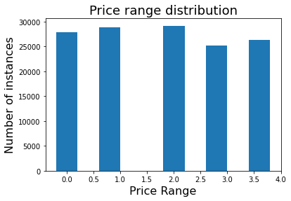

```python
plt.hist(align='left', x=car_df1.price_range.values)
plt.title("Price range distribution", fontsize=18)
plt.xlabel('Price Range', fontsize=16)
plt.ylabel('Number of instances', fontsize=16)
```

We can see from the plot above that the dataset is more balanced now in terms of the class variable 'price_range'. The number of rows present in the dataset for each price_range category is now much closer.

| price_range | Description | Number of rows |
| --- | --- | --- |
| 0 | veryLow | 27942 |
| 1 | low | 28847 |
| 2 | medium | 29192 |
| 3 | high | 25248 |
| 4 | veryHigh | 26297 |

```python
#the model and price fields are no longer required and can be dropped
car_df1 = car_df1.drop(['model','price'],axis=1)
```

#### One Hot Encoding

Data Structure before one hot encoding

```python
car_df1.info()
```

```
<class 'pandas.core.frame.DataFrame'>
RangeIndex: 137526 entries, 0 to 137525
Data columns (total 13 columns):
 #   Column            Non-Null Count   Dtype
---  ------            --------------   -----
 0   price_range       137526 non-null  int64
 1   manufacturer      137526 non-null  object
 2   condition_new     137526 non-null  object
 3   cylinders         137526 non-null  int64
 4   fuel              137526 non-null  object
 5   odometer          137526 non-null  float64
 6   title_status      137526 non-null  object
 7   transmission_new  137526 non-null  object
 8   drive_new         137526 non-null  object
 9   type_new          137526 non-null  object
 10  paint_color_new   137526 non-null  object
 11  state             137526 non-null  object
 12  car_Age_in_yrs    137526 non-null  float64
dtypes: float64(2), int64(2), object(9)
memory usage: 13.6+ MB
```

```python
#One hot encoding using pd.get_dummies
car_df1_ohe=pd.get_dummies(car_df1[['price_range','manufacturer', 'cylinders', 'fuel', 'odometer',
       'title_status', 'state', 'drive_new', 'condition_new',
       'transmission_new', 'type_new', 'paint_color_new', 'car_Age_in_yrs']],drop_first=True)
```

Data structure after one hot encoding

```python
car_df1_ohe.info(verbose=True)
```

```
<class 'pandas.core.frame.DataFrame'>
RangeIndex: 137526 entries, 0 to 137525
Data columns (total 122 columns):
 #    Column                        Dtype
---   ------                        -----
 0    price_range                   int64
 1    cylinders                     int64
 2    odometer                      float64
 3    car_Age_in_yrs                float64
 4    manufacturer_alfa-romeo       uint8
 5    manufacturer_aston-martin     uint8
 6    manufacturer_audi             uint8
 7    manufacturer_bmw              uint8
 8    manufacturer_buick            uint8
 9    manufacturer_cadillac         uint8
```

[output cut: 114 more lines]

```python
car_df1_ohe.describe()
```

|  | price_range | cylinders | odometer | car_Age_in_yrs | manufacturer_alfa-romeo | manufacturer_aston-martin | manufacturer_audi | manufacturer_bmw | manufacturer_buick | manufacturer_cadillac | ... | type_new_crossover | type_new_hatchback | type_new_mini-van | type_new_offroad | type_new_pickup_truck | type_new_sedan | type_new_van | paint_color_new_BluRdBrwn | paint_color_new_Custom | paint_color_new_OrYlwGrnPrpl |
| --- | --- | --- | --- | --- | --- | --- | --- | --- | --- | --- | --- | --- | --- | --- | --- | --- | --- | --- | --- | --- | --- |
| count | 137526.000000 | 137526.000000 | 137526.000000 | 137526.000000 | 137526.000000 | 137526.000000 | 137526.000000 | 137526.000000 | 137526.000000 | 137526.000000 | ... | 137526.000000 | 137526.000000 | 137526.000000 | 137526.000000 | 137526.000000 | 137526.000000 | 137526.000000 | 137526.000000 | 137526.000000 | 137526.000000 |
| mean | 1.949908 | 5.802990 | 99723.645413 | 9.111332 | 0.000320 | 0.000065 | 0.009649 | 0.030627 | 0.012550 | 0.015575 | ... | 0.255275 | 0.059916 | 0.025370 | 0.002610 | 0.239424 | 0.296046 | 0.031172 | 0.244056 | 0.019771 | 0.036909 |
| std | 1.403001 | 1.610902 | 59323.251771 | 6.032133 | 0.017884 | 0.008089 | 0.097755 | 0.172305 | 0.111324 | 0.123826 | ... | 0.436017 | 0.237332 | 0.157246 | 0.051026 | 0.426733 | 0.456513 | 0.173784 | 0.429527 | 0.139212 | 0.188540 |
| min | 0.000000 | 2.000000 | 181.000000 | 1.000000 | 0.000000 | 0.000000 | 0.000000 | 0.000000 | 0.000000 | 0.000000 | ... | 0.000000 | 0.000000 | 0.000000 | 0.000000 | 0.000000 | 0.000000 | 0.000000 | 0.000000 | 0.000000 | 0.000000 |
| 25% | 1.000000 | 4.000000 | 50000.000000 | 5.000000 | 0.000000 | 0.000000 | 0.000000 | 0.000000 | 0.000000 | 0.000000 | ... | 0.000000 | 0.000000 | 0.000000 | 0.000000 | 0.000000 | 0.000000 | 0.000000 | 0.000000 | 0.000000 | 0.000000 |
| 50% | 2.000000 | 6.000000 | 97127.000000 | 8.000000 | 0.000000 | 0.000000 | 0.000000 | 0.000000 | 0.000000 | 0.000000 | ... | 0.000000 | 0.000000 | 0.000000 | 0.000000 | 0.000000 | 0.000000 | 0.000000 | 0.000000 | 0.000000 | 0.000000 |
| 75% | 3.000000 | 8.000000 | 141444.750000 | 13.000000 | 0.000000 | 0.000000 | 0.000000 | 0.000000 | 0.000000 | 0.000000 | ... | 1.000000 | 0.000000 | 0.000000 | 0.000000 | 0.000000 | 1.000000 | 0.000000 | 0.000000 | 0.000000 | 0.000000 |
| max | 4.000000 | 12.000000 | 269781.000000 | 43.000000 | 1.000000 | 1.000000 | 1.000000 | 1.000000 | 1.000000 | 1.000000 | ... | 1.000000 | 1.000000 | 1.000000 | 1.000000 | 1.000000 | 1.000000 | 1.000000 | 1.000000 | 1.000000 | 1.000000 |

8 rows × 122 columns

```python
car_df_spc = car_df1_ohe.copy() #copying the ohe dataset for spectral clustering
```

#### Scaling the dataset

We are using the StandardScaler from sklearn.preprocessing to scale the dataset.

```python
from sklearn.preprocessing import StandardScaler
scl = StandardScaler()
```

```python
y_class = car_df1_ohe['price_range'].values # get the labels we want
del car_df1_ohe['price_range'] # get rid of the class label
X_class = car_df1_ohe.values # use everything else to predict!

X_class = scl.fit_transform(X_class)
```

```python
X = X_class.copy()
y = y_class.copy()
```

X for classification has 121 features and 137,526 instances.

```python
X.shape
```

```
(137526, 121)
```

y has 137,526 instances of the class variable price range with unique values 0 through 4.

```python
y.shape
```

```
(137526,)
```

```python
np.unique(y)
```

```
array([0, 1, 2, 3, 4], dtype=int64)
```

```python
#set n jobs
n_jobs = 20
```

```python
#create cv object
from sklearn.model_selection import StratifiedShuffleSplit
cv = StratifiedKFold(n_splits=10,random_state=42,shuffle=True)
```

#### *Verify data quality: Are there missing values? Duplicate data? Outliers? Are those mistakes? How do you deal with these problems?*

As part of Lab 1, we performed EDA on the original dataset (458,213 rows and 26 fields) and found a lot of missing values, duplicate data, and outliers. Some of the these seemed to be mistakes as well. The following was done to handle each of these scenarios:

##### Missing Values

Several attributes had missing values in the original dataset. We retrieved missing values from the U.S. Department of Transportation VIN API: https://vpic.nhtsa.dot.gov/api/. A scraper was built to call a ReST endpoint and write the details to a file, which was later joined to the original dataset. After retrieving all available missing data, there were still rows with missing values for important attributes. These rows were dropped from the dataset.  
Further details on how missing values were handled can be found in the Lab 1 -> Data Quality-> Missing Values section.

```python
#Missing values in the original dataset
car_df.isna().sum()
```

```
price                0
year              1050
manufacturer     18220
model             4846
condition       192940
cylinders       171140
fuel              3237
odometer         55303
title_status      2577
transmission      2442
VIN             187549
drive           134188
size            321348
type            112738
paint_color     140843
image_url           28
description         70
state                0
posting_date        28
dtype: int64
```

```python
#No missing values in the final/clean dataset
car_df1.isna().sum()
```

```
price_range         0
manufacturer        0
condition_new       0
cylinders           0
fuel                0
odometer            0
title_status        0
transmission_new    0
drive_new           0
type_new            0
paint_color_new     0
state               0
car_Age_in_yrs      0
dtype: int64
```

##### Duplicate Data

There were duplicate records in the dataset because the same car could be listed in multiple regions. We identified duplicate records by checking whether a vehicle instance was unique across all columns in the dataset. If there were multiple records with identical values, then the duplicate records were removed.  
We also created new features to handle some of the inconsistent values that had the same meaning, e.g., in the 'Drive' column, there were values of '4wd' and 'Four wd.' These values were recategorized into a new column (see 'New features' section below).

##### Outliers

The price, year, and odometer columns had some major outliers. A lot of the extreme outliers seemed to be mistakes (e.g., USD 3.5 billion for price, 1900 for year). We implemented a quantile method to screen out the outliers. We set the upper limit for the quantile to be 0.99 and lower limit to be 0.01.

Price, Year and Odometer box plots before removing outliers: From the plot below, the original dataset had extreme values between USD 2.5M and 3.5B. These were removed from the dataset. Reference: Lab 1 Jupyter notebook. Please see Lab 1 'Outlier's section for code details.

We had a few outliers for Year (year built) between 1900 - 1910. These were removed from the dataset.

Similarly, we had outliers for 'Odometer' with a few cars having extremly high odometer readings of 3 million miles. This must be a mistake, but because there is no way to get the correct odometer reading for these rows, we handled them as outliers and removed them from the dataset.

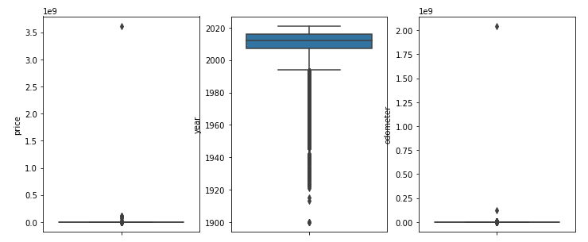

```python
from IPython.display import Image
Image("outliers1.png")
```

Price, Year and Odometer box plots after removing the outliers: We implemented a quantile method to screen out the outliers. We set the upper limit for the quantile to be 0.99 and lower limit to be 0.01. After removing the outliers, the max. price was capped around 52K, the minimum year of a car was 1975, and the max. odometer reading was around 275K.

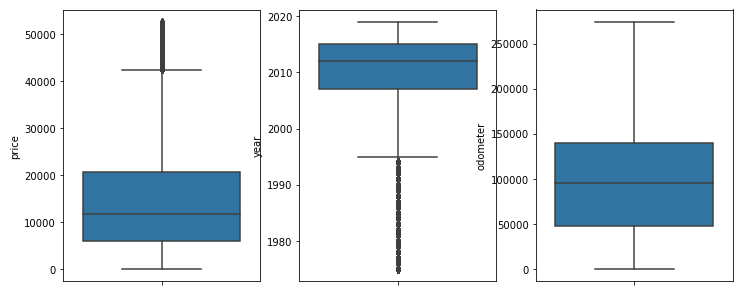

```python
from IPython.display import Image
Image("outliers2.png")
```

The plot below shows the cook's D distribution of the clean dataset. The max influence as shown in the plot below is 0.0175 which is quite low and indicates that there are no major outliers present in the clean dataset. Reference: Please see Lab 2 section 'Model 1: Linear Regression' for more details of this plot.

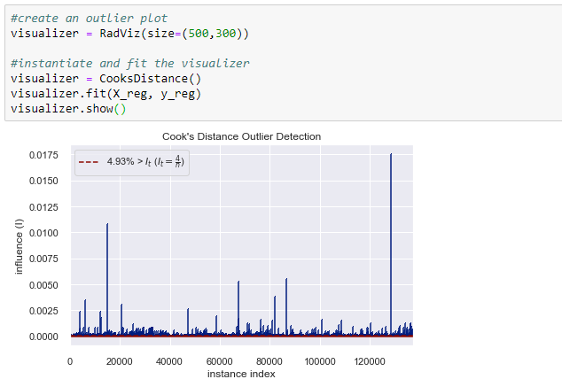

```python
from IPython.display import Image
Image("cooksd.png")
```

##### Mistakes

As stated in the outliers section above, a lot of extreme outliers in the price, year and odometer columns seemed to be mistakes. We did not correct any of these, but instead removed them from the dataset using a quantile method to screen out the outliers.

##### New features created in Lab 1

As part of Lab 1, the following features were created:

1. price_range: The price column was split into multiple price ranges and a categorical column was created. We regrouped these values for project 2 into more balanced classes. Price_range is grouped into the following values: 'Less than 5K','5K-9K','9K-15K','15K-24K','>24K'. These values are then coded into a corresponding integer value of 0 through 4.
2. car_Age_in_yrs: A new field for age of the car was derived by subtracting the year of the car from the posting date.
3. The following columns were recategorized by grouping similar values:

   i) drive_new was derived from drive  
   ii) condition_new from condition  
   iii) transmission_new from transmission  
   iv) type_new from type  
   v) paint_color_new from paint_color

## Data Understanding 2

#### *Visualize the important attributes appropriately. Important: Provide an interpretation for any charts or graphs.*

#### A Random Forest model is used to determine the most important features

```python
%%time
from sklearn.ensemble import RandomForestClassifier
num_estimators = 150

rfc = RandomForestClassifier(max_depth=100, n_estimators=num_estimators,
                             random_state=42,oob_score=False, n_jobs=n_jobs)

yhat = np.zeros(y.shape)

for train, test in cv.split(X,y):
    rfc.fit(X[train],y[train])
    yhat[test] = rfc.predict(X[test])
```

```
Wall time: 1min 5s
```

```python
#get the important features
weights = rfc.feature_importances_
feature_names = car_df1_ohe.columns
rfc_ft_imp_df = pd.DataFrame({'feature_names':feature_names, 'weights':weights, 'absolute_weights': np.abs(weights)})
rfc_ft_imp_df.sort_values(by='absolute_weights', inplace=True, ascending=False )
```

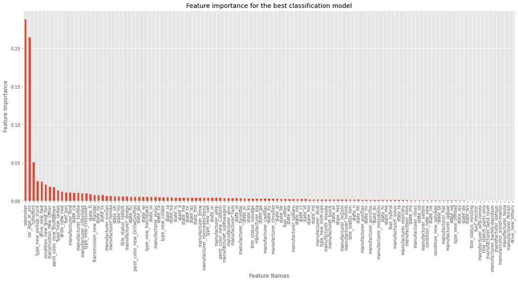

```python
#plot the important features
import matplotlib.pyplot as plt
%matplotlib inline
#Plot the model's feature importances
# REFERENCE:  Eric Larson, https://github.com/eclarson/DataMiningNotebooks
plt.style.use('ggplot')
wt_plt_df = rfc_ft_imp_df
weights = pd.Series(wt_plt_df['weights'].values,index=wt_plt_df['feature_names'])
ax = weights.plot(kind='bar', figsize=(20,8))
ax.set_title("Feature importance for the best classification model")
ax.set_ylabel("Feature Importance")
ax.set_xlabel("Feature Names")
plt.show()
```

**Most Important Attributes**  
The most important attributes in the dataset are odometer, car_Age_in_yrs, and cylinders based on the impurity score from a Random Forest classification model as shown in the Random Forest feature importance plot above. Even though cylinders is the 3rd most important attribute, we can see from the bar plot that the importance of the feature is much lower than odometer and car_Age_in_years. The weight of importance for odometer and car_Age_in_yrs is over 0.2, while the weight for cylinders is only 0.05

We can see that the odometer has the most importance in determining the price range classification of a car. This observation makes sense as we know that the value of a car depreciates with increasing mileage. It is a common indicator of wear and tear on a car and cars that are new with fewer miles can typically command higher prices in the used car market. The next most importance feature is the car_Age_in_yrs. Again, common knowledge tells us that the value of a car depreciates with increased age. We can also say that there is correlation between age of cars and odometer as cars with a higher age tend to have higher odometer readings. The third most important feature is cylinders. Typically, a higher number of cylinders is associated with premium / sports cars, which are usually not sold at lower values in the used car markets. Normally trucks have six or more cylinders and therefore it makes sense to see that trucks are also negatively correlated with the price segment.

#### Plots of the top three most important features

```python
#scatterplots for the most important features
import matplotlib
matplotlib.axes.Axes.scatter
matplotlib.pyplot.scatter
matplotlib.axes.Axes.legend
matplotlib.pyplot.legend
matplotlib.collections.PathCollection.legend_elements
```

```
<function matplotlib.collections.PathCollection.legend_elements(self, prop='colors', num='auto', fmt=None, func=<function PathCollection.<lambda> at 0x0000026CF7026C10>, **kwargs)>
```

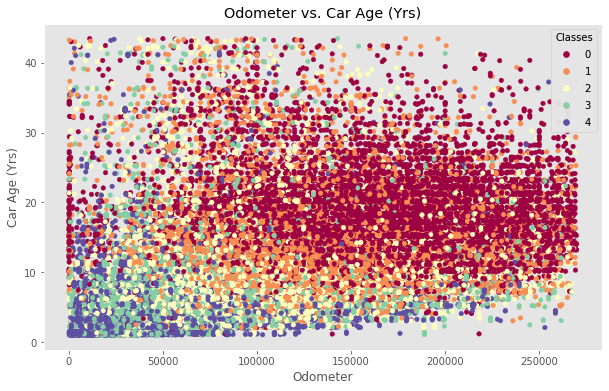

```python
#odometer and car age
fig, ax = plt.subplots(figsize=(10,6))
scatter = ax.scatter(car_df1['odometer'], car_df1['car_Age_in_yrs']+np.random.random(car_df1['car_Age_in_yrs'].shape)/2, s=20, c=car_df1['price_range'], cmap='Spectral')

# produce a legend with the unique colors from the scatter
legend1 = ax.legend(*scatter.legend_elements(),
                    loc="best", title="Classes")
ax.add_artist(legend1)

# produce a legend with a cross section of sizes from the scatter
handles, labels = scatter.legend_elements(prop="sizes", alpha=0.6)
plt.xlabel('Odometer'), plt.ylabel('Car Age (Yrs)')
plt.grid()
plt.title('Odometer vs. Car Age (Yrs)')
plt.show()
```

**Odometer vs. Car Age (Yrs)**  
Although there are observations from all price ranges throughout the plot, there is a gradual trend that shows that as car mileage and car age increases, the price range moves from the highest price range category to the lowest. This supports the intuition that in general the price range of a car goes down as a car's mileage and age increases. The large concentration of purple observations in the bottom left corner shows that cars in the highest price range category (Class 4 - 'Very High') have the lowest odometer values and ages. The purple observations taper off as the odometer and age values increase. There are also very few 'Low' priced observations in the bottom left corner to support this intuition. Moving slightly to the right and up, there is a concentration of green observations, which is the 'High' price range (Class 3). This trend progresses to yellow or 'Medium' priced cars (Class 2), then orange or 'Low' priced cars (Class 1), to red or 'Very Low' priced cars (Class 0).

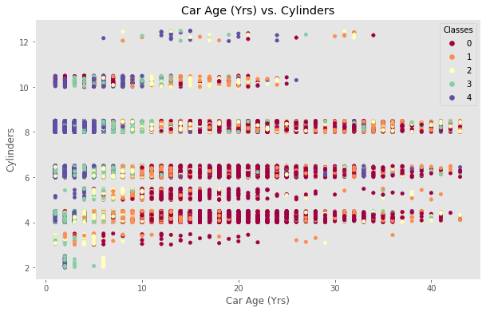

```python
#car age and cylinders
fig, ax = plt.subplots(figsize=(10,6))
scatter = ax.scatter(car_df1['car_Age_in_yrs'], car_df1['cylinders']+np.random.random(car_df1['cylinders'].shape)/2, s=20, c=car_df1['price_range'], cmap='Spectral')

# produce a legend with the unique colors from the scatter
legend1 = ax.legend(*scatter.legend_elements(),
                    loc="best", title="Classes")
ax.add_artist(legend1)

# produce a legend with a cross section of sizes from the scatter
handles, labels = scatter.legend_elements(prop="sizes", alpha=0.6)
plt.xlabel('Car Age (Yrs)'), plt.ylabel('Cylinders')
plt.grid()
plt.title('Car Age (Yrs) vs. Cylinders')
plt.show()
```

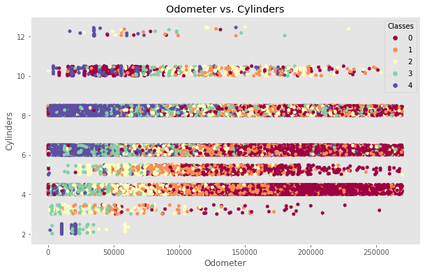

```python
#odometer and cylinders
fig, ax = plt.subplots(figsize=(10,6))
scatter = ax.scatter(car_df1['odometer'], car_df1['cylinders']+np.random.random(car_df1['cylinders'].shape)/2, s=20, c=car_df1['price_range'], cmap='Spectral')

# produce a legend with the unique colors from the scatter
legend1 = ax.legend(*scatter.legend_elements(),
                    loc="best", title="Classes")
ax.add_artist(legend1)

# produce a legend with a cross section of sizes from the scatter
handles, labels = scatter.legend_elements(prop="sizes", alpha=0.6)
plt.xlabel('Odometer'), plt.ylabel('Cylinders')
plt.grid()
plt.title('Odometer vs. Cylinders')
plt.show()
```

**Odometer vs. Cylinders**  
The concentration of purple 'Very High' observations (Class 4) on the left side of the plot again indicates that lower odometer values are generallly associated with higher prices. For cylinders, the concentration of purple 'Very High' priced cars is in 8-cylinder cars with low mileage, followed by 6-cylinders. For the red 'Very Low' priced cars (Class 0), the concentration of observations is above 150,000 miles in the 4, 5, and 6 cylinder groups. However, there are a surprising number of cars below 50,000 miles in the 10-cylinder category. Although there are not many 2-cylinder cars in the dataset, it's interesting that they are all in the 'Very High', 'High', and 'Medium' price ranges and have less than 60,000 miles.

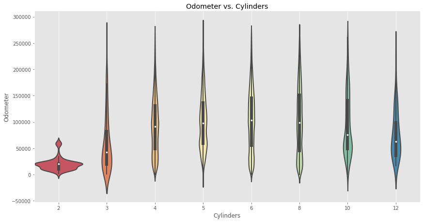

```python
#violin plot
plt.figure(figsize=(12,8))
sns.catplot(x=car_df1['cylinders'], y=car_df1['odometer'], data=car_df1, kind='violin', aspect=2, height=6, linewidth=2, width=1, palette='Spectral')

plt.xlabel('Cylinders'), plt.ylabel('Odometer')
plt.grid()
plt.title('Odometer vs. Cylinders')
plt.show()
```

**Odometer vs. Cylinders**  
The violin plot above shows the density of distribution by car cylinders. On the left side of the plot, there is a high density of cars with lower odometer readings for 2-cylinder cars. The other cyclinders have odometer readings that are much more spread out and range from 0 to almost 300,000. The white dots in the middle of the plots represent the median odometer readings for each category of cylinders. The medians increase as cyclinders increase from 2 to 6 cylinders. After peaking over 100,000 miles for 6-cylinder cars, the median starts decreasing again as the cylinders goes from 6 to 12. 4, 5, and 6 cyclinder cars have a median odometer near 100,000 miles.

## Modeling and Evaluation 1

**Train and adjust parameters**

The following clustering models will be trained and tuned: KMeans, DBSCAN, Spectral, and Hierarchical Agglomerative Clustering (HAC).

### KMeans

KMeans is a clustering algorithm that groups similiar data together in order to discover similiarities. The parameters tuned are:

- **n_clusters:** The number of clusters and number of centroids to generate. The default is 8. A range of values between 1 and 10 will be tested. The elbow method will be used to determine the optimal number.

For the other parameters, the default values are used. K-means++ is the default value for the 'init' parameter and we chose to use this to help speed up the convergence.

Reference: https://scikit-learn.org/stable/modules/generated/sklearn.cluster.KMeans.html

#### The elbow method is used to find the optimal number of clusters (n_clusters)

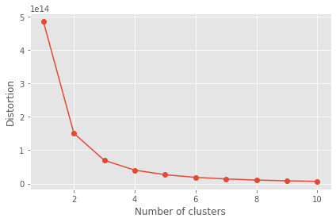

```python
#find optimal n_clusters via the elbow method
from sklearn.cluster import KMeans
distortions = []
X_km, y_km = car_df1_ohe.iloc[:, 1:].values, car_df1_ohe.iloc[:, 0].values
for i in range(1, 11):
    km = KMeans(n_clusters=i, init='k-means++', n_init=10, max_iter=300, random_state=42)
    km.fit(X_km)
    distortions.append(km.inertia_)
plt.plot(range(1, 11), distortions, marker='o')
plt.xlabel('Number of clusters')
plt.ylabel('Distortion')
plt.tight_layout()
plt.show()
```

#### KMeans Results: Train and Adjust Parameters

The optimal number of clusters for KMeans clustering is 3 because it has the steepest descendent in the plot above. Adding to the number of clusters does not reduce the distortion very much. The average silhouette score for the KMeans model with 3 clusters is 0.57.

```python
#final model
final_km = KMeans(n_clusters=3, init='k-means++', n_init=10, max_iter=300, random_state=42)
labels_km = final_km.fit_predict(X_km)
silhouette_score_km = round(mt.silhouette_score(X_km, labels_km),4)
print('Highest Silhouette Score: %s' % silhouette_score_km)
```

```
Highest Silhouette Score: 0.5698
```

### DBSCAN

DBSCAN is a density based clustering algorithm. The parameters tuned here are:

- **eps:** The maximum distance between two samples for one to be considered in the neighborhood of the other. The default is 0.5. A range of values between 0.5 and 5.0 will be tested.
- **min_samples:** The number of samples in a neighborhood for a point to be considered a core point. The default is 5. A range of values between 3 to 5 will be tested.

Reference: https://scikit-learn.org/stable/modules/generated/sklearn.cluster.DBSCAN.html

```python
from sklearn.cluster import DBSCAN
from sklearn.metrics import silhouette_samples, silhouette_score
```

```python
X_dbs = X_class.copy()
y_dbs = y_class.copy()
```

```python
#find the best eps and min_samples for DBSCAN
dbs_df = pd.DataFrame(columns=['eps','min_samples','silhouette'])
```

```python
%%time
for eps in [0.5, 1.0, 3.0, 5.0]:
    for mpts in range(3, 6):

        # append on the clustering
        cls_fam_dbs = DBSCAN(eps=eps, min_samples=mpts, n_jobs=n_jobs)
        cls_fam_dbs.fit_predict(X_dbs)
        newfeature_fam = cls_fam_dbs.labels_ # the labels from clustering
        silhouette_avg_dbs = mt.silhouette_score(X_dbs, cls_fam_dbs.labels_)
        dbs_df = dbs_df.append({'eps':eps,
              'min_samples':mpts,
                'silhouette':silhouette_avg_dbs}, ignore_index=True)
```

```
Wall time: 2h 9min 59s
```

```python
dbs_df
```

|  | eps | min_samples | silhouette |
| --- | --- | --- | --- |
| 0 | 0.5 | 3.0 | -0.083399 |
| 1 | 0.5 | 4.0 | -0.203782 |
| 2 | 0.5 | 5.0 | -0.284304 |
| 3 | 1.0 | 3.0 | 0.064682 |
| 4 | 1.0 | 4.0 | -0.044617 |
| 5 | 1.0 | 5.0 | -0.124630 |
| 6 | 3.0 | 3.0 | 0.220516 |
| 7 | 3.0 | 4.0 | 0.184442 |
| 8 | 3.0 | 5.0 | 0.155539 |
| 9 | 5.0 | 3.0 | 0.177936 |
| 10 | 5.0 | 4.0 | 0.172497 |
| 11 | 5.0 | 5.0 | 0.166018 |

#### DBSCAN Results: Train and Adjust Parameters

```python
#final model
final_dbs = DBSCAN(eps=3, min_samples=3, n_jobs=n_jobs)
labels_dbs = final_dbs.fit_predict(X_dbs)
silhouette_dbs = round(mt.silhouette_score(X_dbs, labels_dbs), 4)

#number of clusters determined by DBSCAN
n_clusts_dbs = final_dbs.labels_[final_dbs.labels_==-1].size
```

```python
print('Highest Silhouette Score: %s' % silhouette_dbs)
print('Number of clusters %s' % n_clusts_dbs)
```

```
Highest Silhouette Score: 0.2205
Number of clusters 19984
```

### Spectral Clustering

Spectral Clustering is a clustering algorithm that uses eigenvalues of matrices built from the dataset to determine the best clustering. PCA will be used to reduce the dimensionality of the dataset and the parameters tuned here are:

- **n_clusters:** The dimension of the projection subspace. The default is 8. A range of clusters will be tested.
- **affinity:** This sets how to construct the affinity matrix. The default is 'rbf.' 'rbf', 'nearest_neighbors', and 'precomputed' will be tested.

Reference: https://scikit-learn.org/stable/modules/generated/sklearn.cluster.SpectralClustering.html

When Spectral Clustering was run on the full dataset and subsets of 30,000 or 20,000 instances, there was a memory error: "MemoryError: Unable to allocate 141. GiB for an array with shape (137526, 137526) and data type float64". 10,000 instances had no issues with memory errors so that is used below.

```python
# Random sample of 10,000 instances due to the memory error
car_df_10k=car_df_spc.sample(n=10000, random_state=42)
X10k, y10k = car_df_10k.iloc[:, 1:].values, car_df_10k.iloc[:, 0].values
```

#### The elbow curve is used to find the optimum number of clusters (n_clusters)

```python
# references: http://github.com/ciortanmadalina/high_noise_clustering/blob/master/spectral_clustering.ipynb

import scipy
from scipy.sparse import csgraph
# from scipy.sparse.linalg import eigsh
from numpy import linalg as LA
def eigenDecomposition(A, plot = True, topK = 5):
    """
    :param A: Affinity matrix
    :param plot: plots the sorted eigen values for visual inspection
    :return A tuple containing:
    - the optimal number of clusters by eigengap heuristic
    - all eigen values
    - all eigen vectors

    This method performs the eigen decomposition on a given affinity matrix,
    following the steps recommended in the paper:
    1. Construct the normalized affinity matrix: L = D−1/2ADˆ −1/2.
    2. Find the eigenvalues and their associated eigen vectors
    3. Identify the maximum gap which corresponds to the number of clusters
    by eigengap heuristic

    References:
    https://papers.nips.cc/paper/2619-self-tuning-spectral-clustering.pdf
    http://www.kyb.mpg.de/fileadmin/user_upload/files/publications/attachments/Luxburg07_tutorial_4488%5b0%5d.pdf
    """
    L = csgraph.laplacian(A, normed=True)
    n_components = A.shape[0]

    # LM parameter : Eigenvalues with largest magnitude (eigs, eigsh), that is, largest eigenvalues in
    # the euclidean norm of complex numbers.
#     eigenvalues, eigenvectors = eigsh(L, k=n_components, which="LM", sigma=1.0, maxiter=5000)
    eigenvalues, eigenvectors = LA.eig(L)

    if plot:
        plt.title('Largest eigen values of input matrix')
        plt.scatter(np.arange(len(eigenvalues)), eigenvalues)
        plt.grid()

    # Identify the optimal number of clusters as the index corresponding
    # to the larger gap between eigen values
    index_largest_gap = np.argsort(np.diff(eigenvalues))[::-1][:topK]
    nb_clusters = index_largest_gap + 1

    return nb_clusters, eigenvalues, eigenvectors
```

```python
# references: http://github.com/ciortanmadalina/high_noise_clustering/blob/master/spectral_clustering.ipynb

from scipy.spatial.distance import pdist, squareform
def getAffinityMatrix(coordinates, k = 7):
    """
    Calculate affinity matrix based on input coordinates matrix and the number
    of nearest neighbours.

    Apply local scaling based on the k nearest neighbour
        References:
    https://papers.nips.cc/paper/2619-self-tuning-spectral-clustering.pdf
    """
    # calculate euclidian distance matrix
    dists = squareform(pdist(coordinates))

    # for each row, sort the distances ascendingly and take the index of the
    #k-th position (nearest neighbour)
    knn_distances = np.sort(dists, axis=0)[k]
    knn_distances = knn_distances[np.newaxis].T

    # calculate sigma_i * sigma_j
    local_scale = knn_distances.dot(knn_distances.T)

    affinity_matrix = dists * dists
    affinity_matrix = -affinity_matrix / local_scale
    # divide square distance matrix by local scale
    affinity_matrix[np.where(np.isnan(affinity_matrix))] = 0.0
    # apply exponential
    affinity_matrix = np.exp(affinity_matrix)
    np.fill_diagonal(affinity_matrix, 0)
    return affinity_matrix
```

```
Optimal number of clusters [260 776 842 966 998]
Wall time: 8min 44s
```

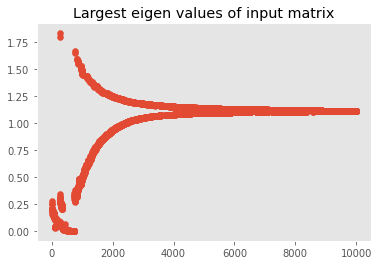

```python
%%time
affinity_matrix = getAffinityMatrix(X10k, k = 10)
k, _,  _ = eigenDecomposition(affinity_matrix)
print(f'Optimal number of clusters {k}')
```

#### Spectral Clustering: n_clusters

```python
from sklearn.preprocessing import StandardScaler, normalize
# Scaling the data
sc=StandardScaler()
X10k_scaled=sc.fit_transform(X10k)

# Normalizing the data
X10k_normalized=normalize(X10k_scaled)

# Converting numpy array to pd dataframe
X10k_normalized=pd.DataFrame(X10k_normalized)
```

```python
# Dimensions reduction
from sklearn.decomposition import PCA
PCA=PCA(n_components=2)
X10k_PCA=PCA.fit_transform(X10k_normalized)
X10k_PCA=pd.DataFrame(X10k_PCA)
X10k_PCA.columns=['P1','P2']
X10k_PCA.head()
```

|  | P1 | P2 |
| --- | --- | --- |
| 0 | 0.557129 | -0.085245 |
| 1 | -0.234139 | 0.131450 |
| 2 | -0.010119 | -0.028059 |
| 3 | -0.142604 | -0.038291 |
| 4 | 0.305313 | 0.214384 |

#### Affinity: Nearest Neighbors

```python
from sklearn.cluster import SpectralClustering
spc_nn = SpectralClustering(n_clusters=260, affinity = 'nearest_neighbors',random_state=42, n_jobs=n_jobs)
labels_nn = spc_nn.fit_predict(X10k_PCA)
```

#### Affinity: Precomputed

```python
from sklearn.neighbors import kneighbors_graph
Xknn = kneighbors_graph(X10k_PCA, 10)

spc_pre = SpectralClustering(n_clusters=260, affinity = 'precomputed',random_state=42, n_jobs=n_jobs)
labels_pre = spc_pre.fit_predict(Xknn)
```

```
C:\Program Files\Python38\lib\site-packages\sklearn\utils\validation.py:63: UserWarning: Array is not symmetric, and will be converted to symmetric by average with its transpose.
  return f(*args, **kwargs)
```

#### Affinity: rbf

```python
%%time
spc_rbf = SpectralClustering(n_clusters=260,random_state=42, n_jobs=n_jobs)
labels_rbf = spc_rbf.fit_predict(X10k_PCA)
```

```
Wall time: 16min 26s
```

#### Affinity Results

Below are the silhouette scores for the affinity parameters nearest neighbors, precomputed, and rbf.

```python
from sklearn.metrics import silhouette_score

#List of different values of affinity
affinity=['precomputed','nearest_neighbors','rbf']

#List of Silhouette Scores
s_scores=[]

#Evaluating the performance
s_scores.append(silhouette_score(X10k_PCA, labels_nn))
s_scores.append(silhouette_score(X10k_PCA, labels_pre))
s_scores.append(silhouette_score(X10k_PCA, labels_rbf))
print(s_scores)
```

```
[0.29365821062712183, 0.29625109385306553, 0.015184012326869615]
```

#### Spectral Clustering Results: Train and Adjust Parameters

```python
#final model
final_spc = SpectralClustering(n_clusters=260, affinity = 'nearest_neighbors',random_state=42, n_jobs=n_jobs)
labels_spc = final_spc.fit_predict(X10k_PCA)
silhouette_avg_spc = round(mt.silhouette_score(X10k_PCA, labels_spc), 4)
print('Highest Silhouette Score: %s' % silhouette_avg_spc)
```

```
Highest Silhouette Score: 0.2937
```

### Hierarchical Agglomerative Clustering (HAC)

Agglomerative Clustering is a clustering algorithm that builds a hierarchy of clusters. The parameters tuned below are:

- **n_clusters:** The number of clusters. The default is 2. A range of values between 1 and 10 will be tested.
- **linkage:** This determines which distance to use between sets of observations. The default is 'ward.' 'ward', 'average', and 'complete' will be tested.

Reference: https://scikit-learn.org/stable/modules/generated/sklearn.cluster.AgglomerativeClustering.html

```python
#tuning
from sklearn.cluster import AgglomerativeClustering
car_df_5k=car_df_spc.sample(n=5000, random_state=42)

X5k, y5k = car_df_5k.iloc[:, 1:].values, car_df_5k.iloc[:, 0].values

#List of Silhouette Scores
s_scores_hac=[]

for link in ['ward', 'complete', 'average']:
    for nclusts in range(2, 11):
        cls_fam = AgglomerativeClustering(n_clusters=nclusts, linkage=link)
        cls_fam.fit_predict(X5k)
        newfeature_fam = cls_fam.labels_ # the labels from hac clustering
        silhouette_avg_hac = round(mt.silhouette_score(X5k, cls_fam.labels_),4)
        s_scores_hac.append(silhouette_score(X5k, cls_fam.labels_))
        print("C=", nclusts, link,"Average Silhouette = ", silhouette_avg_hac)
```

```
C= 2 ward Average Silhouette =  0.5387
C= 3 ward Average Silhouette =  0.5677
C= 4 ward Average Silhouette =  0.5039
C= 5 ward Average Silhouette =  0.5245
C= 6 ward Average Silhouette =  0.4988
C= 7 ward Average Silhouette =  0.5115
C= 8 ward Average Silhouette =  0.516
C= 9 ward Average Silhouette =  0.5081
C= 10 ward Average Silhouette =  0.509
C= 2 complete Average Silhouette =  0.5039
C= 3 complete Average Silhouette =  0.5712
C= 4 complete Average Silhouette =  0.5422
C= 5 complete Average Silhouette =  0.5438
C= 6 complete Average Silhouette =  0.5072
C= 7 complete Average Silhouette =  0.4989
C= 8 complete Average Silhouette =  0.4954
C= 9 complete Average Silhouette =  0.4859
C= 10 complete Average Silhouette =  0.4872
C= 2 average Average Silhouette =  0.5833
C= 3 average Average Silhouette =  0.5194
C= 4 average Average Silhouette =  0.5
C= 5 average Average Silhouette =  0.5145
C= 6 average Average Silhouette =  0.5078
C= 7 average Average Silhouette =  0.5373
C= 8 average Average Silhouette =  0.5264
C= 9 average Average Silhouette =  0.5081
C= 10 average Average Silhouette =  0.5279
```

#### Hierarchical Agglomerative Clustering Results: Train and Adjust Parameters

Of the 27 combinations trained, the optimal number of clusters for HAC is 2 and the linkage value 'average' produces the highest silhouette score at 0.583. Adding clusters reduces the silhouette score slightly. This method resulted in the highest silhouette score of all the clustering algorithms.

```python
#optimal model based on parameters with the best silhouette score
from sklearn.cluster import AgglomerativeClustering

final_ac = AgglomerativeClustering(n_clusters=2, affinity='euclidean', linkage='average')
labels = final_ac.fit_predict(X5k)
s_score_hac = round(mt.silhouette_score(X5k, labels), 4)
print('Highest Silhouette Score: %s' % s_score_hac)
```

```
Highest Silhouette Score: 0.5833
```

## Modeling and Evaluation 2

*Evaluate and Compare*

After finding the optimal hyperparameters for each of the four clustering algorithms, we created a new feature for clusters and used it in a Random Forest Classification model to see if it improved the accuracy of the model.

### Baseline Random Forest model without adding a cluster feature

#### Full Dataset

```python
#reset X & y
X = X_class.copy()
y = y_class.copy()
```

```python
#set the scoring parameters
scorer = {'accuracy': make_scorer(accuracy_score),
                 'precision': make_scorer(precision_score, average='weighted',zero_division=0),
                 'recall': make_scorer(recall_score, average='weighted', zero_division=0),
                  'f1_score': make_scorer(f1_score, average='weighted', zero_division=0)
                 }
```

```python
rfc = RandomForestClassifier(max_depth=100, n_estimators=num_estimators,
                             random_state=42,oob_score=False, n_jobs=n_jobs)
```

```python
%%time
#code for the Random Forest Model with Accuracy, Precision, Recall, F1, etc.
scores_bl = cross_validate(rfc, X, y, scoring=scorer, cv=cv, return_train_score=True, n_jobs=n_jobs)
acc_bl = round(scores_bl['test_accuracy'].mean()*100,2)
prec_bl = round(scores_bl['test_precision'].mean()*100,2)
rec_bl = round(scores_bl['test_recall'].mean()*100,2)
f1_bl = round(scores_bl['test_f1_score'].mean()*100,2)
```

```
Wall time: 52.3 s
```

```python
print("Random Forest Accuracy Baseline", acc_bl)
print("Random Forest Precision Baseline", prec_bl)
print("Random Forest Recall Baseline", rec_bl)
print("Random Forest f1 score Baseline", f1_bl)
```

```
Random Forest Accuracy Baseline 82.24
Random Forest Precision Baseline 82.27
Random Forest Recall Baseline 82.24
Random Forest f1 score Baseline 82.25
```

The accuracy for the Random Forest model without any cluster features is 82.24%.

#### Sampled Dataset (10K)

```python
%%time
#code for the Random Forest Model with Accuracy, Precision, Recall, F1, etc.
scores_bl_10k = cross_validate(rfc, X10k, y10k, scoring=scorer, cv=cv, return_train_score=True, n_jobs=n_jobs)
acc_bl_10k = round(scores_bl_10k['test_accuracy'].mean()*100,2)
prec_bl_10k = round(scores_bl_10k['test_precision'].mean()*100,2)
rec_bl_10k = round(scores_bl_10k['test_recall'].mean()*100,2)
f1_bl_10k = round(scores_bl_10k['test_f1_score'].mean()*100,2)
```

```
Wall time: 3.05 s
```

```python
print("Random Forest Accuracy Baseline", acc_bl_10k)
print("Random Forest Precision Baseline", prec_bl_10k)
print("Random Forest Recall Baseline", rec_bl_10k)
print("Random Forest f1 score Baseline", f1_bl_10k)
```

```
Random Forest Accuracy Baseline 71.16
Random Forest Precision Baseline 71.33
Random Forest Recall Baseline 71.16
Random Forest f1 score Baseline 71.18
```

The accuracy for the Random Forest model without any cluster features for a 10K sampled dataset is 71.16%.

#### Sampled Dataset (5K)

```python
%%time
#code for the Random Forest Model with Accuracy, Precision, Recall, F1, etc.
scores_bl_5k = cross_validate(rfc, X5k, y5k, scoring=scorer, cv=cv, return_train_score=True, n_jobs=n_jobs)
acc_bl_5k = round(scores_bl_5k['test_accuracy'].mean()*100,2)
prec_bl_5k = round(scores_bl_5k['test_precision'].mean()*100,2)
rec_bl_5k = round(scores_bl_5k['test_recall'].mean()*100,2)
f1_bl_5k = round(scores_bl_5k['test_f1_score'].mean()*100,2)
```

```
Wall time: 1.18 s
```

```python
print("Random Forest Accuracy Baseline", acc_bl_5k)
print("Random Forest Precision Baseline", prec_bl_5k)
print("Random Forest Recall Baseline", rec_bl_5k)
print("Random Forest f1 score Baseline", f1_bl_5k)
```

```
Random Forest Accuracy Baseline 67.46
Random Forest Precision Baseline 67.55
Random Forest Recall Baseline 67.46
Random Forest f1 score Baseline 67.41
```

The accuracy for the Random Forest model without any cluster features for a 5K sampled dataset is 67.46%.

Next we will try to add a cluster feature to the model to attempt to improve the metrics. A summary table of results is presented at the end of this section.

### KMeans

```python
#reset X & y
X = X_class.copy()
y = y_class.copy()
```

```python
results_df = pd.DataFrame(columns=['model','n_clusters','silhouette','acc (baseline)','acc (with clusters)', 'precision','recall', 'f1'])
```

```python
%%time
from sklearn.metrics import classification_report
from sklearn.model_selection import StratifiedKFold, cross_val_score
from sklearn.ensemble import RandomForestClassifier
from sklearn import metrics as mt

cv = StratifiedKFold(n_splits=10,random_state=42,shuffle=True)
clf = RandomForestClassifier(n_estimators=150,random_state=42, n_jobs=n_jobs)


cls = KMeans(n_clusters=3, init='k-means++',random_state=42)
cls.fit(X)
newfeature = cls.labels_ # the labels from kmeans clustering

X = np.column_stack((X,newfeature))


yhat=np.zeros(y.shape)
for train, test in cv.split(X,y):
    clf.fit(X[train],y[train])
    yhat[test]=clf.predict(X[test])

acc_km  = round(mt.accuracy_score(y,yhat)*100, 2)
prec_km = round(mt.precision_score(y,yhat, average='weighted')*100,2)
rec_km = round(mt.recall_score(y,yhat, average='weighted')*100,2)
f1_km = round(mt.f1_score(y,yhat, average='weighted')*100, 2)
```

```
Wall time: 1min 7s
```

```python
results_df = results_df.append({'model':'KMeans',
                'silhouette':silhouette_score_km,
               'n_clusters':3,
                'acc (baseline)':acc_bl,
                'acc (with clusters)':acc_km,
                'precision':prec_km,
                'recall':rec_km,
                'f1':f1_km}, ignore_index=True)
```

```python
#get the important features
weights_km = clf.feature_importances_
new_col = pd.Index(['cluster'])
feature_names_km = car_df1_ohe.columns
feature_names_km = feature_names_km.append([new_col])
rfc_ft_imp_df_km = pd.DataFrame({'feature_names':feature_names_km, 'weights':weights_km, 'absolute_weights': np.abs(weights_km)})
rfc_ft_imp_df_km.sort_values(by='absolute_weights', inplace=True, ascending=False )
```

```python
#Placeholder for gini index
gini_index = pd.DataFrame(columns=['Gini index','cluster_num'])

#Define number of clusters
n_clusters_gini = 3 #Number of clusters
n_cluster_gini_lp = pd.Series(range(0,n_clusters_gini))

#n_cluster_gini_lp
#Pass cluster output
cluster_output = labels_km #cluster output

#cluster_output
#Merge y and cluster output to create a dataframe
y_gini = pd.DataFrame(np.column_stack((y,cluster_output)))
y_gini = y_gini.set_axis(['y','n'], axis=1)
#y_gini

# Adapted from:
# https://www.featureranking.com/tutorials/machine-learning-tutorials/information-gain-computation/
for clust_num in n_cluster_gini_lp:
    y_gini2 = y_gini[y_gini['n']==clust_num]['y']
    probs = pd.value_counts(y_gini2,normalize=True)
    gini_indx = 1 - np.sum(np.square(probs))
    #print('gini_indx',gini_indx)
    gini_index = gini_index.append({'Gini index':gini_indx,'cluster_num':clust_num,}, ignore_index=True)
gini_index_kmeans = gini_index
#gini_index_kmeans
```

```python
results_df[results_df['model']=='KMeans']
```

|  | model | n_clusters | silhouette | acc (baseline) | acc (with clusters) | precision | recall | f1 |
| --- | --- | --- | --- | --- | --- | --- | --- | --- |
| 0 | KMeans | 3 | 0.5698 | 82.24 | 82.12 | 82.14 | 82.12 | 82.13 |

The elbow method was used to determine the appropriate number of clusters for the KMeans algorithm. The optimal number was determined to be three as shown in the Modeling and Evaluation 1 section. The silhouette score for the model with 3 clusters is 0.57 which is the second highest score for the clustering methods used in this analysis.

To get the accuracy, precision, recall, and f1 score, 10-fold cross validation was run on the Random Forest Classifier. The model performance was basically the same as the baseline model after adding the KMeans clusters as a feature. The accuracy was 82.12% compared to 82.24% accuracy of the baseline model.

### DBSCAN

```python
X = X_class.copy()
y = y_class.copy()

X2 = X_class.copy()
y2 = y_class.copy()
```

```python
%%time

clf_dbs = RandomForestClassifier(n_estimators=150,random_state=42, n_jobs=n_jobs)

cls_fam_dbs = DBSCAN(eps=0.3, min_samples=3, n_jobs=n_jobs)
cls_fam_dbs.fit_predict(X)
newfeature_fam_dbs = cls_fam_dbs.labels_.astype(np.uint8) # the labels from dbs clustering
silhouette_avg_dbs = mt.silhouette_score(X, cls_fam_dbs.labels_)

X2 = np.column_stack((X2,newfeature_fam_dbs))

yhat=np.zeros(y.shape)
for train, test in cv.split(X2,y2):
    clf_dbs.fit(X2[train],y2[train])
    yhat[test]=clf_dbs.predict(X2[test])

acc_dbs  = round(mt.accuracy_score(y2,yhat)*100, 2)
prec_dbs = round(mt.precision_score(y2,yhat, average='weighted')*100,2)
rec_dbs = round(mt.recall_score(y2,yhat, average='weighted')*100,2)
f1_dbs = round(mt.f1_score(y2,yhat, average='weighted')*100, 2)
```

```
Wall time: 12min 7s
```

```python
results_df = results_df.append({'model':'DBSCAN',
                'silhouette':silhouette_dbs,
               'n_clusters':n_clusts_dbs,
                'acc (baseline)':acc_bl,
                'acc (with clusters)':acc_dbs,
                'precision':prec_dbs,
                'recall':rec_dbs,
                'f1':f1_dbs}, ignore_index=True)
```

```python
#get the important features
weights_dbs = clf_dbs.feature_importances_
new_col = pd.Index(['cluster'])
feature_names_dbs = car_df1_ohe.columns
feature_names_dbs = feature_names_dbs.append([new_col])
rfc_ft_imp_df_dbs = pd.DataFrame({'feature_names':feature_names_dbs, 'weights':weights_dbs, 'absolute_weights': np.abs(weights_dbs)})
rfc_ft_imp_df_dbs.sort_values(by='absolute_weights', inplace=True, ascending=False )
```

```python
#Placeholder for gini index
gini_index = pd.DataFrame(columns=['Gini index','cluster_num'])

#Define number of clusters
n_clusters_gini = n_clusts_dbs #Number of clusters
n_cluster_gini_lp = pd.Series(range(0,n_clusters_gini))
#n_cluster_gini_lp

#Pass cluster output
cluster_output = labels_dbs #cluster output

#Merge y and cluster output to create a dataframe
y_gini = pd.DataFrame(np.column_stack((y,cluster_output)))
y_gini = y_gini.set_axis(['y','n'], axis=1)
#y_gini

# Adapted from:
# https://www.featureranking.com/tutorials/machine-learning-tutorials/information-gain-computation/
for clust_num in n_cluster_gini_lp:
    y_gini2 = y_gini[y_gini['n']==clust_num]['y']
    probs = pd.value_counts(y_gini2,normalize=True)
    gini_indx = 1 - np.sum(np.square(probs))
    gini_index = gini_index.append({'Gini index':gini_indx,'cluster_num':clust_num,}, ignore_index=True)
gini_index_dbscan = gini_index
#gini_index_dbscan
```

```python
results_df[results_df['model']=='DBSCAN']
```

|  | model | n_clusters | silhouette | acc (baseline) | acc (with clusters) | precision | recall | f1 |
| --- | --- | --- | --- | --- | --- | --- | --- | --- |
| 1 | DBSCAN | 19984 | 0.2205 | 82.24 | 82.06 | 82.09 | 82.06 | 82.07 |

To get the accuracy, precision, recall, and f1 score, 10-fold cross validation was run on the Random Forest Classifier. The model did not improve from the baseline after adding the DBSCAN clusters as a feature with an accuracy of 82.06%.

### Spectral Clustering

```python
from sklearn.metrics import classification_report
from sklearn.model_selection import StratifiedKFold, cross_val_score
from sklearn.ensemble import RandomForestClassifier
from sklearn import metrics as mt

cv = StratifiedKFold(n_splits=10,random_state=42,shuffle=True)
clf = RandomForestClassifier(n_estimators=150,random_state=42, n_jobs=n_jobs)

spc_nn = SpectralClustering(n_clusters=260, affinity = 'nearest_neighbors',random_state=42, n_jobs=n_jobs)
newfeature_nn = spc_nn.fit_predict(X10k)

X_spc = np.column_stack((X10k,newfeature_nn))

y10khat=np.zeros(y10k.shape)
for train, test in cv.split(X_spc,y10k):
    clf.fit(X_spc[train],y10k[train])
    y10khat[test]=clf.predict(X_spc[test])

acc_spec = round(mt.accuracy_score(y10k,y10khat)*100, 2)
prec_spec = round(mt.precision_score(y10k,y10khat, average='weighted')*100, 2)
rec_spec = round(mt.recall_score(y10k,y10khat, average='weighted')*100, 2)
f1_spec = round(mt.f1_score(y10k,y10khat, average='weighted')*100,2)
```

```
C:\Program Files\Python38\lib\site-packages\sklearn\manifold\_spectral_embedding.py:245: UserWarning: Graph is not fully connected, spectral embedding may not work as expected.
  warnings.warn("Graph is not fully connected, spectral embedding"
```

```python
results_df = results_df.append({'model':'Spectral*',
                'silhouette':silhouette_avg_spc,
               'n_clusters':260,
                'acc (baseline)':acc_bl_10k,
                'acc (with clusters)':acc_spec,
                'precision':prec_spec,
                'recall':rec_spec,
                'f1':f1_spec}, ignore_index=True)
```

```python
#get the important features
weights_spc = clf.feature_importances_
new_col = pd.Index(['cluster'])
feature_names_spc = car_df1_ohe.columns
feature_names_spc = feature_names_spc.append([new_col])
rfc_ft_imp_df_spc = pd.DataFrame({'feature_names':feature_names_spc, 'weights':weights_spc, 'absolute_weights': np.abs(weights_spc)})
rfc_ft_imp_df_spc.sort_values(by='absolute_weights', inplace=True, ascending=False )
```

```python
#Placeholder for gini index
gini_index = pd.DataFrame(columns=['Gini index','cluster_num'])

#Define number of clusters
n_clusters_gini = 260 #Number of clusters
n_cluster_gini_lp = pd.Series(range(0,n_clusters_gini))
#n_cluster_gini_lp

#Pass cluster output
cluster_output = labels_spc #cluster output

#Merge y and cluster output to create a dataframe
y_gini = pd.DataFrame(np.column_stack((y10k,cluster_output)))
y_gini = y_gini.set_axis(['y','n'], axis=1)
#y_gini

# Adapted from:
# https://www.featureranking.com/tutorials/machine-learning-tutorials/information-gain-computation/
for clust_num in n_cluster_gini_lp:
    y_gini2 = y_gini[y_gini['n']==clust_num]['y']
    probs = pd.value_counts(y_gini2,normalize=True)
    gini_indx = 1 - np.sum(np.square(probs))
    gini_index = gini_index.append({'Gini index':gini_indx,'cluster_num':clust_num,}, ignore_index=True)
gini_index_spectral = gini_index
#gini_index_spectral
```

```python
results_df[results_df['model']=='Spectral*']
```

|  | model | n_clusters | silhouette | acc (baseline) | acc (with clusters) | precision | recall | f1 |
| --- | --- | --- | --- | --- | --- | --- | --- | --- |
| 2 | Spectral* | 260 | 0.2937 | 71.16 | 71.04 | 71.12 | 71.04 | 71.06 |

The eigenvalue/eigenvector curve was used to determine the appropriate number of clusters of the Spectral Clustering algorithm. The optimal number was determined to be 260 as shown in the Modeling and Evaluation 1 section. The silhouette score for the model with 260 clusters is 0.29. This score was lower compared to KMeans or Hierarchical Agglomerative Clustering.

To get the accuracy, precision, recall, and f1 score, 10-fold cross validation was run on the Random Forest Classifier. The metrics were slightly lower than the baseline model after adding the Spectral clusters as a feature with an accuracy of 71.04%.

### Hierarchical Agglomerative Clustering

```python
X = X_class.copy()
y = y_class.copy()
```

```python
%%time

# Random sample of 5000 instances due to memory error.

from sklearn.cluster import AgglomerativeClustering
#run RF model with the new feature

clf_hac = RandomForestClassifier(n_estimators=150,random_state=42, n_jobs=n_jobs)

cls_fam = AgglomerativeClustering(n_clusters=2, affinity='euclidean', linkage='average')
cls_fam.fit(X5k)
newfeature_fam = cls_fam.labels_ # the labels from HAC clustering
X = np.column_stack((X5k, newfeature_fam))

yhat5k = np.zeros(y5k.shape)

for train, test in cv.split(X,y5k):
    clf_hac.fit(X[train],y5k[train])
    yhat5k[test] = clf_hac.predict(X[test])
```

```
Wall time: 5.17 s
```

```python
acc_hac = round(mt.accuracy_score(y5k,yhat5k)*100, 2)
prec_hac = round(mt.precision_score(y5k,yhat5k, average='weighted')*100, 2)
rec_hac = round(mt.recall_score(y5k,yhat5k, average='weighted')*100, 2)
f1_hac = round(mt.f1_score(y5k,yhat5k, average='weighted')*100,2)
```

```python
results_df = results_df.append({'model':'HAC*',
                'silhouette':s_score_hac,
               'n_clusters':2,
                'acc (baseline)':acc_bl_5k,
                'acc (with clusters)':acc_hac,
                'precision':prec_hac,
                'recall':rec_hac,
                'f1':f1_hac}, ignore_index=True)
```

```python
#get the important features
weights_hac = clf_hac.feature_importances_
new_col = pd.Index(['cluster'])
feature_names_hac = car_df1_ohe.columns
feature_names_hac = feature_names_hac.append([new_col])
rfc_ft_imp_df_hac = pd.DataFrame({'feature_names':feature_names_hac, 'weights':weights_hac, 'absolute_weights': np.abs(weights_hac)})
rfc_ft_imp_df_hac.sort_values(by='absolute_weights', inplace=True, ascending=False )
```

```python
#Placeholder for gini index
gini_index = pd.DataFrame(columns=['Gini index','cluster_num'])

#Define number of clusters
n_clusters_gini = 2 #Number of clusters
n_cluster_gini_lp = pd.Series(range(0,n_clusters_gini))

#n_cluster_gini_lp
#Pass cluster output
cluster_output = labels #cluster output

#Merge y and cluster output to create a dataframe
y_gini = pd.DataFrame(np.column_stack((y5k,cluster_output)))
y_gini = y_gini.set_axis(['y','n'], axis=1)
#y_gini

# Adapted from:
# https://www.featureranking.com/tutorials/machine-learning-tutorials/information-gain-computation/
for clust_num in n_cluster_gini_lp:
    y_gini2 = y_gini[y_gini['n']==clust_num]['y']
    probs = pd.value_counts(y_gini2,normalize=True)
    gini_indx = 1 - np.sum(np.square(probs))
    gini_index = gini_index.append({'Gini index':gini_indx,'cluster_num':clust_num,}, ignore_index=True)
gini_index_hac = gini_index
#gini_index_hac
```

```python
results_df[results_df['model']=='HAC*']
```

|  | model | n_clusters | silhouette | acc (baseline) | acc (with clusters) | precision | recall | f1 |
| --- | --- | --- | --- | --- | --- | --- | --- | --- |
| 3 | HAC* | 2 | 0.5833 | 67.46 | 67.68 | 67.67 | 67.68 | 67.67 |

The silhouette score was used to determine the appropriate number of clusters for the Hierarchical Agglomerative Clustering algorithm. The optimal number was determined to be 2 as shown in the Modeling and Evaluation 1 section. The silhouette score for the model with 2 clusters and linkage='average' was 0.583. This score was highest score compared with all the other clustering algorithms.

To get the accuracy, precision, recall, and f1 score, 10-fold cross validation was run on the Random Forest Classifier. The metrics were slightly higher than the baseline model after adding the HAC clusters as a feature with an accuracy of 67.68%. Overall this model has the lowest accuracy, which is likely due to the fact that it only uses a sampled dataset of 5K samples, but adding the cluster feature slightly improved the model.

### Conclusion: Evaluate and Compare

Below are is a summary of results for each clustering method.

```python
results_df
```

|  | model | n_clusters | silhouette | acc (baseline) | acc (with clusters) | precision | recall | f1 |
| --- | --- | --- | --- | --- | --- | --- | --- | --- |
| 0 | KMeans | 3 | 0.5698 | 82.24 | 82.12 | 82.14 | 82.12 | 82.13 |
| 1 | DBSCAN | 19984 | 0.2205 | 82.24 | 82.06 | 82.09 | 82.06 | 82.07 |
| 2 | Spectral* | 260 | 0.2937 | 71.16 | 71.04 | 71.12 | 71.04 | 71.06 |
| 3 | HAC* | 2 | 0.5833 | 67.46 | 67.68 | 67.67 | 67.68 | 67.67 |

**The Spectral model was run on 10K samples because of memory constraints using the full dataset. The HAC model was run on 5K samples for the same reason.*

To evaluate and compare clustering techniques, we generated a new cluster feature based on the best parameters from training/adjusting the cluster models. The new feature was then added to the dataset before running the Random Forest Classification model again. The results were compared to a baseline Random Forest classification model without the cluster feature.

After adding each cluster feature to Random Forest Classification model, the KMeans clusters produced the highest metrics with an accuracy of 82.12, precision of 82.14, recall of 82.12, and f1 score of 82.13. However, only the HAC model improved with the cluster features and the improvement was very minor from 67.46% to 67.68% accuracy.

HAC model produced the highest silhouette score of 0.5833. This was the only model that showed a minor improvement on the baseline model.

## Modeling and Evaluation 3

*Visualize Results*

### KMeans

```python
X, y = car_df_spc.iloc[:, 1:].values, car_df_spc.iloc[:, 0].values
```

```
0.5697946255163515
```

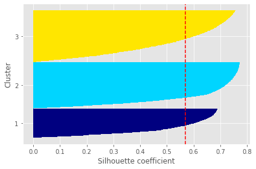

```python
from matplotlib import cm

km = KMeans(n_clusters=3, init='k-means++', n_init=10, max_iter=300, tol=1e-04, random_state=42)
y_km = km.fit_predict(X)

cluster_labels = np.unique(y_km)
n_clusters = cluster_labels.shape[0]
silhouette_vals = silhouette_samples(X, y_km, metric='euclidean')
y_ax_lower, y_ax_upper = 0, 0
yticks = []
for i, c in enumerate(cluster_labels):
    c_silhouette_vals = silhouette_vals[y_km == c]
    c_silhouette_vals.sort()
    y_ax_upper += len(c_silhouette_vals)
    color = cm.jet(float(i) / n_clusters)
    plt.barh(range(y_ax_lower, y_ax_upper), c_silhouette_vals, height=1.0,
             edgecolor='none', color=color)

    yticks.append((y_ax_lower + y_ax_upper) / 2.)
    y_ax_lower += len(c_silhouette_vals)

silhouette_avg_km = np.mean(silhouette_vals)
print(silhouette_avg_km)
plt.axvline(silhouette_avg_km, color="red", linestyle="--")

plt.yticks(yticks, cluster_labels + 1)
plt.ylabel('Cluster')
plt.xlabel('Silhouette coefficient')

plt.tight_layout()
#plt.savefig('images/11_04.png', dpi=300)
plt.show()
```

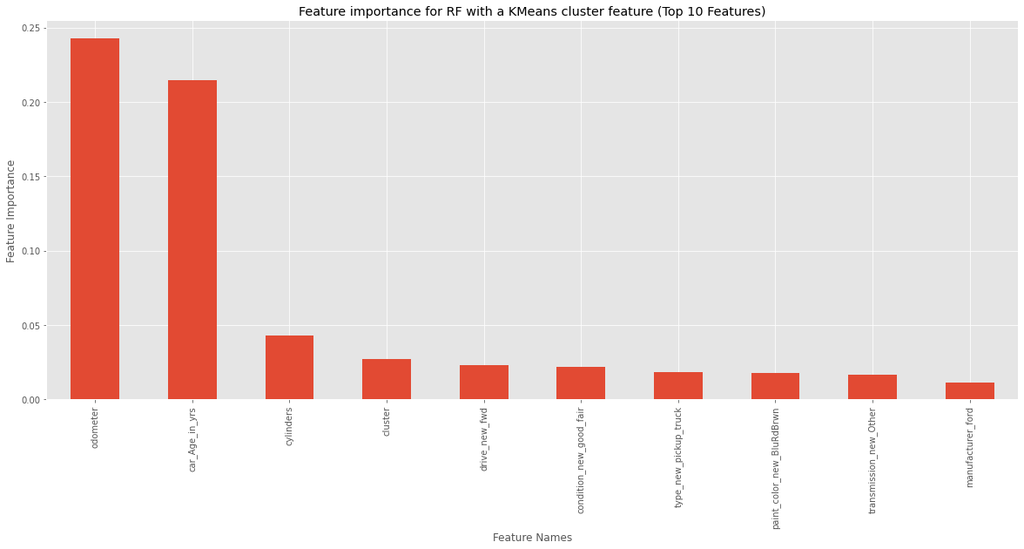

```python
#plot the important features
import matplotlib.pyplot as plt
%matplotlib inline
#Plot the model's feature importances
# REFERENCE:  Eric Larson, https://github.com/eclarson/DataMiningNotebooks
plt.style.use('ggplot')
wt_plt_df_km = rfc_ft_imp_df_km.head(n=10)
weights_km = pd.Series(wt_plt_df_km['weights'].values,index=wt_plt_df_km['feature_names'])
ax = weights_km.plot(kind='bar', figsize=(20, 8))
ax.set_title("Feature importance for RF with a KMeans cluster feature (Top 10 Features)")
ax.set_ylabel("Feature Importance")
ax.set_xlabel("Feature Names")
plt.show()
```

**KMeans Feature Importance**  
After adding the KMeans 'cluster' feature to the dataset and running the Random Forest Classifier, we see that the 'cluster' feature has become the 4th most important feature following odometer, car_Age_in_yrs, and cylinders. The feature importance weight of 'odometer' and 'car_Age_in_yrs' is very high at over 0.2. The weight for 'cluster' is only about 0.03 which is slightly below the 'cylinder' feature with a weight of 0.04. Even though 'cluster' is the 4th most important feature now, it does not provide any improvement to the model metrics as shown in Modeling and Evaluation 2.

### DBSCAN

#### PCA with DBSCAN

```python
X = X_class.copy()
y = y_class.copy()
```

```python
features = X.T
cov_matrix = np.cov(features)
values, vectors = np.linalg.eig(cov_matrix)
```

```python
projected_1 = X.dot(vectors.T[0])
projected_2 = X.dot(vectors.T[1])

result = pd.DataFrame(projected_1, columns=['PC1'])
result['PC2']=projected_2
result['Y'] = y
```

```python
X_pca = result[['PC1','PC2']]
y_pca = result['Y']
```

```python
X_pca_df = X_pca.copy()
```

```python
X_pca = X_pca.values
```

```python
%%time
#DBSCAN with PC1 & 2
cls = DBSCAN(eps=0.1, min_samples=5, n_jobs=n_jobs)
cls.fit_predict(X_pca)
dbs_labels = cls.labels_.astype(np.uint8)
```

```
Wall time: 2.83 s
```

```python
cls.labels_[cls.labels_==-1].size
```

```
670
```

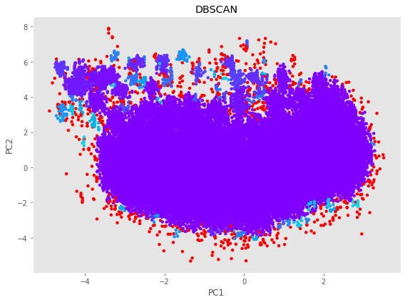

```python
#Density plot
fig = plt.figure(figsize=(8, 6))
title = 'DBSCAN'

plt.scatter(X_pca[:, 0], X_pca[:, 1]+np.random.random(X_pca[:, 1].shape)/2, c=dbs_labels, cmap=plt.cm.rainbow, s=20, linewidths=0)
plt.xlabel('PC1'), plt.ylabel('PC2')
plt.grid()
plt.title(title)

plt.tight_layout()
plt.show()
```

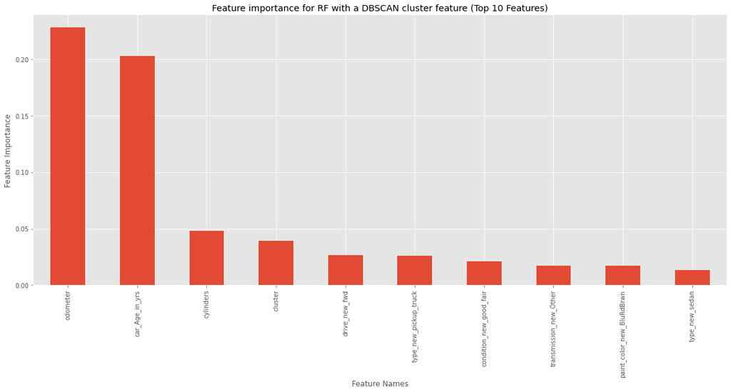

```python
%matplotlib inline
#Plot the model's feature importances
# REFERENCE:  Eric Larson, https://github.com/eclarson/DataMiningNotebooks
plt.style.use('ggplot')
wt_plt_df_dbs = rfc_ft_imp_df_dbs.head(n=10)
weights_dbs = pd.Series(wt_plt_df_dbs['weights'].values,index=wt_plt_df_dbs['feature_names'])
ax = weights_dbs.plot(kind='bar', figsize=(20, 8))
ax.set_title("Feature importance for RF with a DBSCAN cluster feature (Top 10 Features)")
ax.set_ylabel("Feature Importance")
ax.set_xlabel("Feature Names")
plt.show()
```

### Spectral Clustering

The three plots below show clusters for three different types of affinity parameters for Spectral Clustering. PCA was used to reduce the dimensionality of the dataset for the purposes of visualizing the clusters. These plots are based on the 10K sampled dataset in order to avoid computational memory errors.

#### Affinity: Nearest Neighbors

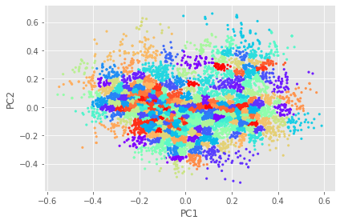

```python
plt.scatter(x=X10k_PCA['P1'],y=X10k_PCA['P2'], c=labels_nn,cmap=plt.cm.rainbow, s=10, linewidths=0)
plt.xlabel('PC1')
plt.ylabel('PC2')
plt.tight_layout()
plt.show()
```

**Nearest Neighbors Affinity**  
With 260 clusters previously defined through the eigenvalues/eigenvectors elbow curve and with the affinity matrix of 'nearest neighbors' which computes a graph of nearest neighbors, the plot of spectral clustering above shows good clustering visually using the PCA algorithm for dimension reduction. There are some missed clusterings on the datapoints that spread around the edges of the main cluster area which is due to the large size of the dataset and the high number of clusters. It also can be caused by the human eye which is not accustomed to distinguishing 260 different colors on the plot. However, the overall result of Spectral clustering between PC1 and PC2 works as intended and the spectral algorithm performs nicely on this large dataset.

#### Affinity: Precomputed

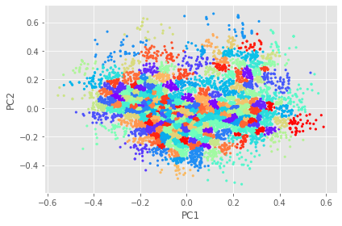

```python
plt.scatter(x=X10k_PCA['P1'],y=X10k_PCA['P2'], c=labels_pre,cmap=plt.cm.rainbow, s=10, linewidths=0)
plt.xlabel('PC1')
plt.ylabel('PC2')
plt.tight_layout()
plt.show()
```

**Precomputed Affinity**  
The affinity matrix of 'precomputed' is interpreting X, which in this case is PC1, as a precomputed affinity matrix. Again we use the PCA algorithm for dimension reduction so that we can visually plot the clusters. We see that there are missing clusters on some datapoints that scatter around the edges of the main cluster area which could be caused by a high number of clusters, large datasets, and an untrained human eye to distinguish 260 different colors. In conclusion, the spectral clustering plot between PC1 and PC2 seems to do its job and the spectral algorithm performs well on this dataset.

#### Affinity: rbf

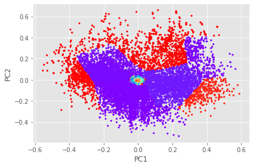

```python
plt.scatter(x=X10k_PCA['P1'],y=X10k_PCA['P2'], c=labels_rbf,cmap=plt.cm.rainbow, s=10, linewidths=0)
plt.xlabel('PC1')
plt.ylabel('PC2')
plt.tight_layout()
plt.show()
```

**rbf Affinity**  
The affinity of 'rbf' which stands for radial basis function constructs the affinity matrix though the rbf kernel. This is a default value for the Spectral clustering algorithm. The PCA algorithm is used for plotting purposes to reduce the dimension of the dataset. The result of the Spectral clustering plot between PC1 and PC2 seems poorly fitted even though the number of clusters is 260, the same as nearest neighbor and precomputed affinity. A huge number of datapoints are clustered in the outer zone but the center zone area seems to perform better when comparing it with the outer zone. It's evident that the rbf affinity is not suitable for this dataset. The silhouette score for this affinity of around 0.01 is pretty low compared to the other 2 affinity matrices. This very low silhouette score supports the conclusion that rbf affinity is not suitable for this dataset.

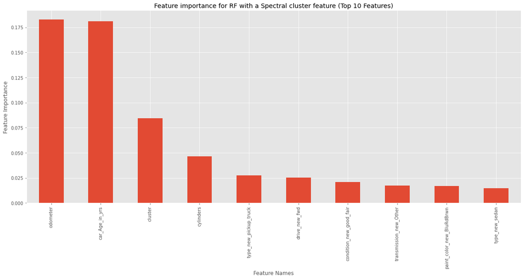

```python
#plot the important features
%matplotlib inline
#Plot the model's feature importances
# REFERENCE:  Eric Larson, https://github.com/eclarson/DataMiningNotebooks
plt.style.use('ggplot')
wt_plt_df_spc = rfc_ft_imp_df_spc.head(n=10)
weights_spc = pd.Series(wt_plt_df_spc['weights'].values,index=wt_plt_df_spc['feature_names'])
ax = weights_spc.plot(kind='bar', figsize=(20, 8))
ax.set_title("Feature importance for RF with a Spectral cluster feature (Top 10 Features)")
ax.set_ylabel("Feature Importance")
ax.set_xlabel("Feature Names")
plt.show()
```

**Spectral Clustering Feature Importance**  
When the Spectral 'cluster' feature was added to the dataset and the Random Forest Classifier was run, the 'cluster' feature became the 3rd most important feature following odometer adn car_Age_in_yrs, with a weight of 0.08. This beats the cylinder weight of 0.05. It still did not improve the model's metrics which seems to indicate that 'car_Age_in_yrs' and 'odometer' are truly the most important features for this dataset using the Random Forest Classifier.

### HAC

This dendrogram plot for HAC is based on the 5K sampled dataset in order to avoid computational memory errors.

```
(4999, 4)
```

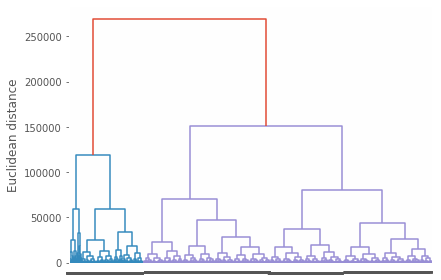

```python
from scipy.cluster.hierarchy import dendrogram
from scipy.cluster.hierarchy import linkage
from scipy.spatial.distance import pdist

row_clusters = linkage(pdist(car_df_5k, metric='euclidean'), method='complete')
print(row_clusters.shape)
# make dendrogram black (part 1/2)
# from scipy.cluster.hierarchy import set_link_color_palette
# set_link_color_palette(['black'])

row_dendr = dendrogram(row_clusters, labels=labels)
                       # make dendrogram black (part 2/2)
                       # color_threshold=np.inf

plt.tight_layout()
plt.ylabel('Euclidean distance')
#plt.savefig('images/11_11.png', dpi=300,
#            bbox_inches='tight')
plt.show()
```

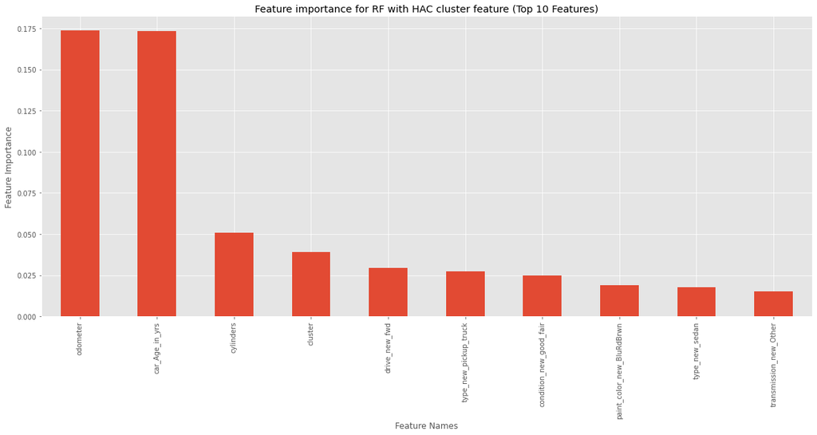

```python
#plot the important features
import matplotlib.pyplot as plt
%matplotlib inline
#Plot the model's feature importances
# REFERENCE:  Eric Larson, https://github.com/eclarson/DataMiningNotebooks
plt.style.use('ggplot')
wt_plt_df_hac = rfc_ft_imp_df_hac.head(n=10)
weights_hac = pd.Series(wt_plt_df_hac['weights'].values,index=wt_plt_df_hac['feature_names'])
ax = weights_hac.plot(kind='bar', figsize=(20,8))
ax.set_title("Feature importance for RF with HAC cluster feature (Top 10 Features)")
ax.set_ylabel("Feature Importance")
ax.set_xlabel("Feature Names")
plt.show()
```

**HAC Feature Importance**  
When the HAC 'cluster' feature was added to the Random Forest Classifier, the importance dropped back down to 4th with a value of 0.04. The 'odometer' and 'car_Age_in_yrs' features have slightly lower weights in this model at less than 0.20. This model is the only one that had a slight improvement to the metrics. This could be related to the fact that the weights of the top two most important features is lower in this model. It's possible clusters are better for this model as indicated by the higher silhouette score. But the overall accuracy for this model is the lowest, probably due the fact that a sampled 5K dataset had to be used to avoid memory allocation errors. This model also had the lowest number of clusters with only two clusters.

## Modeling and Evaluation 4

*Summarize the Ramifications*

#### Building clusters

In this project, we built clusters using the following clustering techniques: KMeans, DBSCAN, Spectral and Hierarchical Agglomerative Clustering.  
To build the most efficient clusters on this dataset, we trained and adjusted the hyperparameters below for each clustering algorithm. The set of parameters that provided the best (highest) silhouette score was then picked and the final clustering algorithms were implemented:

- Kmeans: n_clusters = 3
- DBScan: eps = 3.0 and min_samples = 3
- Spectral Clustering: n_clusters = 260 and affinity = 'nearest neighbors'
- HAC: n_clusters = 2 and linkage = 'average'

#### Visualizing clusters

These visualizations can be seen in the section 'Modeling and Evaluation 3'.

#### Passing the cluster output to the Random Forest Classifier

After finding the optimal hyperparameters for each clustering algorithm, we added the cluster output as a new feature to the dataset, this new feature was then used to build a classification model. As part of Lab 2, the Random Forest Classification model produced the best performance metrics on this dataset. We picked this model and used it as a baseline to compare to the new model with the cluster output added as a new feature. To get the accuracy, precision, recall, and f1 score, 10-fold cross validation was run on each Random Forest Classifier model.

The following table summarizes the results for the Random Forest Classfication model with the new feature for each clustering technique:

```python
results_df
```

|  | model | n_clusters | silhouette | acc (baseline) | acc (with clusters) | precision | recall | f1 |
| --- | --- | --- | --- | --- | --- | --- | --- | --- |
| 0 | KMeans | 3 | 0.5698 | 82.24 | 82.12 | 82.14 | 82.12 | 82.13 |
| 1 | DBSCAN | 19984 | 0.2205 | 82.24 | 82.06 | 82.09 | 82.06 | 82.07 |
| 2 | Spectral* | 260 | 0.2937 | 71.16 | 71.04 | 71.12 | 71.04 | 71.06 |
| 3 | HAC* | 2 | 0.5833 | 67.46 | 67.68 | 67.67 | 67.68 | 67.67 |

**The Spectral model was run on 10K samples because of memory constraints using the full dataset. The HAC model was run on 5K samples for the same reason.*

**Number of Clusters**  
The number of clusters for these models ranges from 2 to 19,984. For KMeans and HAC, the values for this parameter were selected based on hypertuning results - the value that produced the best silhouette scores for the parameters tested made it into the final model. The number of clusters for DBSCAN is determined by the model directly, rather than choosing the value to pass to the model. For DBSCAN, after tuning the eps and min_samples to get the highest silhouette score, the model determined that 19,984 was the optimal number of clusters. DBSCAN and Spectral have a much higher number of clusters and the silhouette scores are the lowest for these models.

**Silhouette Scores**  
HAC and KMeans have the highest silhouette scores, but this does not translate to better metrics for the model. The highest silhouette score was 0.5833 for the HAC model and it was the only model that showed a minor improvement in accuracy by about 0.22%.

**Feature Importance By Random Forest Feature Selection**  
After running the Random Forest Classifier with the new cluster feature, we looked at the Random Forest feature selection to see how it ranked the new cluster feature.

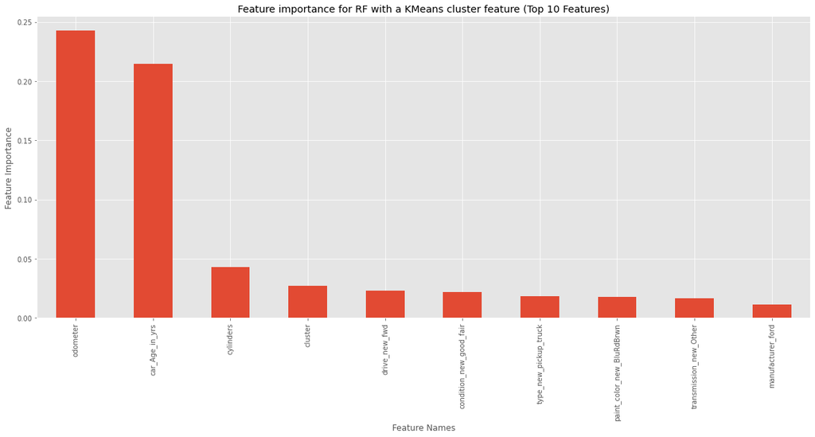

```python
#plot the important features
import matplotlib.pyplot as plt
%matplotlib inline
#Plot the model's feature importances
# REFERENCE:  Eric Larson, https://github.com/eclarson/DataMiningNotebooks
plt.style.use('ggplot')
wt_plt_df_km = rfc_ft_imp_df_km.head(n=10)
weights_km = pd.Series(wt_plt_df_km['weights'].values,index=wt_plt_df_km['feature_names'])
ax = weights_km.plot(kind='bar', figsize=(20,8))
ax.set_title("Feature importance for RF with a KMeans cluster feature (Top 10 Features)")
ax.set_ylabel("Feature Importance")
ax.set_xlabel("Feature Names")
plt.show()
```

The new cluster was 4th most important feature for all the clustering methods except for Spectral where it was the 3rd most important feature. The plot above shows the top 10 features by feature importance with the KMeans'cluster' feature as the 4th most important feature after 'odometer', 'car_Age_in_yrs', and 'cyclinders.' The same plot is shown for the other clustering methods in Modeling and Evaluation 3.

```python
car_df1_gini = car_df_spc.copy()
car_df1_gini['newfeature']=newfeature.tolist()
```

```python
# feature ranking thru gini index definition
#Code provided by Dr. Drew
def gini_index(y):
    probs=pd.value_counts(y, normalize=True)
    return 1-np.sum(np.square(probs))
```

```python
#KMeans
car_df_gini_kmeans=pd.DataFrame(data=car_df1_gini[['odometer','car_Age_in_yrs','cylinders','newfeature','condition_new_good_fair','drive_new_fwd',
                           'type_new_sedan','type_new_crossover','paint_color_new_BluRdBrwn','type_new_pickup_truck']])

for index in car_df_gini_kmeans.columns:
    a= gini_index(car_df_gini_kmeans[index])
    print('Name and gini: ',index, a)
```

```
Name and gini:  odometer 0.9995361765898011
Name and gini:  car_Age_in_yrs 0.9441451463913353
Name and gini:  cylinders 0.6735444828895878
Name and gini:  newfeature 0.5179029132730038
Name and gini:  condition_new_good_fair 0.49946609189045443
Name and gini:  drive_new_fwd 0.4889053215973861
Name and gini:  type_new_sedan 0.4168054000993766
Name and gini:  type_new_crossover 0.3802197071373459
Name and gini:  paint_color_new_BluRdBrwn 0.3689849993425899
Name and gini:  type_new_pickup_truck 0.3642001067920483
```

```python
#DBSCAN
car_df1_gini = car_df_spc.copy()
car_df1_gini['newfeature_fam_dbs']=newfeature_fam_dbs.tolist()
```

```python
car_df_gini_dbscan=pd.DataFrame(data=car_df1_gini[['odometer','car_Age_in_yrs','cylinders','newfeature_fam_dbs','condition_new_good_fair','drive_new_fwd',
                           'type_new_sedan','type_new_crossover','paint_color_new_BluRdBrwn','type_new_pickup_truck']])

for index in car_df_gini_dbscan.columns:
    a= gini_index(car_df_gini_dbscan[index])
    print('Name and gini: ',index, a)
```

```
Name and gini:  odometer 0.9995361765898011
Name and gini:  car_Age_in_yrs 0.9441451463913353
Name and gini:  cylinders 0.6735444828895878
Name and gini:  newfeature_fam_dbs 0.5621078303221582
Name and gini:  condition_new_good_fair 0.49946609189045443
Name and gini:  drive_new_fwd 0.4889053215973861
Name and gini:  type_new_sedan 0.4168054000993766
Name and gini:  type_new_crossover 0.3802197071373459
Name and gini:  paint_color_new_BluRdBrwn 0.3689849993425899
Name and gini:  type_new_pickup_truck 0.3642001067920483
```

```python
#Spectral
car_df1_gini = car_df_10k.copy()
car_df1_gini['newfeature_nn']=newfeature_nn.tolist()
```

```python
#Spectral
car_df_gini_spectral=pd.DataFrame(data=car_df1_gini[['odometer','car_Age_in_yrs','cylinders','newfeature_nn','condition_new_good_fair','drive_new_fwd',
                           'type_new_sedan','type_new_crossover','paint_color_new_BluRdBrwn','type_new_pickup_truck']])

for index in car_df_gini_spectral.columns:
    a= gini_index(car_df_gini_spectral[index])
    print('Name and gini: ',index, a)
```

```
Name and gini:  odometer 0.99944434
Name and gini:  car_Age_in_yrs 0.9442441
Name and gini:  cylinders 0.6755868199999999
Name and gini:  newfeature_nn 0.99574008
Name and gini:  condition_new_good_fair 0.49937341999999996
Name and gini:  drive_new_fwd 0.48632142
Name and gini:  type_new_sedan 0.40857911999999996
Name and gini:  type_new_crossover 0.38209632000000004
Name and gini:  paint_color_new_BluRdBrwn 0.37076471999999994
Name and gini:  type_new_pickup_truck 0.37076471999999994
```

```python
#HAC
car_df1_gini = car_df_5k.copy()
car_df1_gini['newfeature_fam']=newfeature_fam.tolist()
```

```python
#HAC
car_df_gini_hac=pd.DataFrame(data=car_df1_gini[['odometer','car_Age_in_yrs','cylinders','newfeature_fam','condition_new_good_fair','drive_new_fwd',
                           'type_new_sedan','type_new_crossover','paint_color_new_BluRdBrwn','type_new_pickup_truck']])

for index in car_df_gini_hac.columns:
    a= gini_index(car_df_gini_hac[index])
    print('Name and gini: ',index, a)
```

```
Name and gini:  odometer 0.999326
Name and gini:  car_Age_in_yrs 0.94483576
Name and gini:  cylinders 0.67448752
Name and gini:  newfeature_fam 0.48217727999999993
Name and gini:  condition_new_good_fair 0.49918392
Name and gini:  drive_new_fwd 0.4858880000000001
Name and gini:  type_new_sedan 0.41163191999999993
Name and gini:  type_new_crossover 0.38841912
Name and gini:  paint_color_new_BluRdBrwn 0.36018528000000005
Name and gini:  type_new_pickup_truck 0.36954168
```

**Gini Index by Cluster**  
To further analyze this, we then looked at the gini index distribution across all clusters for each clustering technique. The Gini index is a metric that calculates the amount of probability of a specific feature that is classified incorrectly when selected randomly. The following plots show the gini index for each of the clusters for each clustering technique.

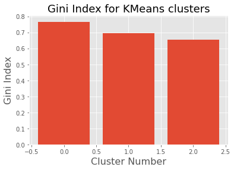

```python
plt.title("Gini Index for KMeans clusters", fontsize=18)
plt.xlabel('Cluster Number', fontsize=16)
plt.ylabel('Gini Index', fontsize=16)
plt.bar(gini_index_kmeans['cluster_num'], gini_index_kmeans['Gini index'])
plt.show()
```

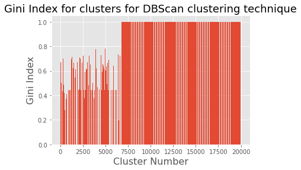

```python
plt.title("Gini Index for clusters for DBScan clustering technique", fontsize=18)
plt.xlabel('Cluster Number', fontsize=16)
plt.ylabel('Gini Index', fontsize=16)
plt.bar(gini_index_dbscan['cluster_num'], gini_index_dbscan['Gini index'])
plt.show()
```

**DBSCAN Gini Index**  
The bar plot above shows the Gini Index for each of the 19,984 clusters that were created using the DBScan clustering technique. The Gini index was calculated by assessing the number of different classes in each cluster. We see a wide range of Gini index values for this clustering technique, with a minimum gini index of 0 (probably a very few clusters), but at the same time we also see that a major chunk of clusters with a gini index of 1, indicating very high impurity. The overall mean gini index for this clustering technique was calcualted at 0.8, indicating high overall impurity. We believe that because of such high gini index values for these clusters, the cluster output as a feature in the dataset did not help improve the accuracy of the Random Forest Classifier model.

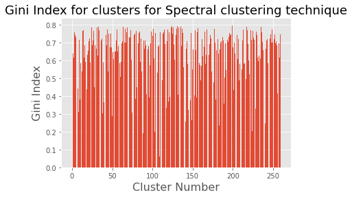

```python
plt.title("Gini Index for clusters for Spectral clustering technique", fontsize=18)
plt.xlabel('Cluster Number', fontsize=16)
plt.ylabel('Gini Index', fontsize=16)
plt.bar(gini_index_spectral['cluster_num'], gini_index_spectral['Gini index'])
plt.show()
```

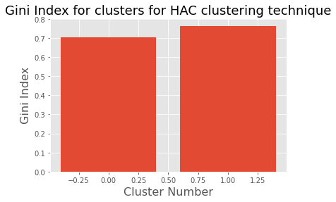

```python
plt.title("Gini Index for clusters for HAC clustering technique", fontsize=18)
plt.xlabel('Cluster Number', fontsize=16)
plt.ylabel('Gini Index', fontsize=16)
plt.bar(gini_index_hac['cluster_num'], gini_index_hac['Gini index'])
plt.show()
```

## Deployment

*Be critical of your performance and tell the reader how your current model might be usable by other parties. Did you achieve your goals? If not, can you reign in the utility of your modeling? How useful is your model for interested parties (i.e., the companies or organizations that might want to use it)? How would your deploy your model for interested parties? What other data should be collected? How often would the model need to be updated, etc.?.*

*Did you achieve your goals?*  
Yes, we believe we achieved the goal of this project of predicting the price range of Craig's list used cars. The best model had an accuracy of 82% which we feel is pretty good. Adding clusters to the model did not improve the model. Clustering can be used in EDA, but building the Random Forest classifier on the dataset (without cluster features) should be sufficient.

*If not, can you reign in the utility of your modeling?*  
We could do better by overcoming the following challenges:

1. Missing values: Our initial dataset had 458,213 rows but a lot of the data was missing. We did bring few attributes from the US Dept. of Transporation, but still there were attributes that had missing information. We had to drop all those rows.
2. Outliers: We had various outliers, could have been mistakes but the extreme ones were handled as outliers and were removed from the dataset.

The above two reasons contributed to us dropping more than half of our dataset. We could probably improve the performance of our model if we could find a way to impute most of these variables (for ex: clustering could be use to impute categorical variables).

3. Computing power: Our final dataset had 121 features and 137,526 instances. There were several models where our computers could not handle this size of the dataset and would get memory errors, thus for those models, we had to limit our dataset to 10K or 5K random samples. We believe we could have done better if we had more computing power or knew ways to handle the dataset of this size using our current available computing power.
4. More models to explore?: We tried all the models and methods that we learned in this class, it will be interesting to see what we learn in the next classes and see if those help us further improve the performance of our model.

*How useful is your model for interested parties (i.e., the companies or organizations that might want to use it)?*  
This model could be a useful research tool for individuals buying or selling a vehicle on Craig's list. In general, we believe this tool will add a lot of value to any company that sells used cars (training data and deployment methods might vary by company), it will help save time for both the sellers and buyers by suggesting sellers the appropriate selling price and buyers the appropriate market price.

- Sellers: This tool will help set competitive pricing for the car that the seller is about to list or has already listed. Or if a seller is having trouble getting responses to a listing, this tool could help with price correction.
- Buyers: A buyer who is interested in a particular car may want to find out if the asking price is fair compared to the other listings. This could save a buyer time by avoiding clicking through many car listings to manually compare car features and prices and would make decision making quicker.

*How would you deploy your model for interested parties?*

Sellers: The relevant features of the car would be gathered from a web form and passed to a trained model. The model would make a prediction and return it to the seller. The seller could choose to use the prediction or set a different price.

Buyers: The application would gather the car's features, pass them to the model, and return an estimated price or price range for the car. Craig's list could also display an icon or symbol indicating whether a car is a good price, similar to the "Good Deal" tag on cars.com where a vehicle's price and features are compared to similiar cars (see example below). The "Good Deal" tag would require an additional calculation to compare the prediction to an actual listing price.  
To take it one step further, it would be useful to present information to the buyer about which features are driving the cost of a car to be higher or lower than other similiar cars. For example, a car without a title might explain why its price is lower than other cars with similiar features. Because the data used to train the model is from Craig's list, the model only makes sense for that site in its current form, but it could be re-trained and deployed to other used car sites with the appropriate data.

[figure not shown]

*What other data should be collected?*  
We believe the current attributes collected captured all the details of the used cars but the following suggestions could add quality to this dataset and might help build better models:

1. Adding Mandatory fields on the web form: We saw missing values in a lot of fields, we believe few fields such as Model, State, manufacturer, odometer reading, Year built, cylinders etc. would always be known to a seller and could be made mandatory.
2. Data validation on the web form to avoid extreme outliers.
3. We could also have additional sources like Kelly Blue Book data presented along with these predictions as another point of comparison when buyers or sellers are trying to gain insights into used car prices.

*How often would the model need to be updated, etc.?.*  
Ideally, this model would be re-trained with new listings once per week and would include the most recent four weeks of data in order to stay relevant with current market conditions. Only inactive or retired listings would be used to train the model. This may require using data a month or two in the past.

For any of these tools, there should be a disclaimer that the predicted prices are based on past Craig's list vehicle listings in the set date range and may not reflect the quality or the true value of the car.

## Exceptional Work

*You have free reign to provide additional analyses or combine analyses.*

We would like to request exceptional points for two items:

1. Passing the cluster output as a new feature to the classification model: For each clustering technique, we added the cluster output as a feature to the dataset, then created classification models to evaluate if the corresponding clusters help improve model performance. We also performed 10-fold cross validation and created a confusion matrix to assess the performance of the models comparing the baseline models (without the cluster output) to the model with the cluster output as one of the features in the dataset. See Modeling and Evaluation 2 for the corresponding code and Modeling and Evaluation 4 for the comparison results and conclusion.
2. Intercluster Distance Map showing the distance of cluster centers embedded into a two-dimensional space. This was created on KMeans clusters. See details below.

#### Intercluster Distance Map

```python
X = X_class.copy()
y = y_class.copy()
```

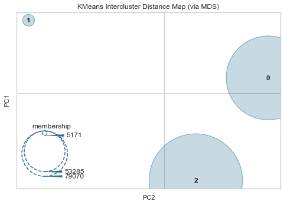

```python
#intercluster distance plot from yellowbrick:  https://www.scikit-yb.org/en/latest/api/cluster/icdm.html
cls = KMeans(n_clusters=3, init='k-means++',random_state=42)
cls.fit(X)
from yellowbrick.cluster import InterclusterDistance
visualizer=InterclusterDistance(cls)
visualizer.fit(X)
visualizer.show()
```

**KMeans Intercluster Distance Map**  
The above intercluster distance plot is showing an embedding of cluster centers in 2 dimensional space with the distance to the other centers preserved using the KMeans clustering algorithm. The number of clusters is 3 with the default embedding value of multidimensional scaling (MDS). Clusters closer to the center of the plot indicate that the clusters are closer to the original feature space. Cluster 0 and 2 look closer to the center compared to Cluster 1. Cluster 1 seems to be the farthest away from the center, which indicates a sparse cluster. The smaller the cluster is on the plot, the smaller the number of points. Cluster 1 has the smallest cluster drawn which means it has the smallest number of points for that cluster whereas cluster 2 is the biggest cluster indicating that it has the largest number of points.